University of Tehran , school of ECE  
Data Analytics Course  
Fall 2022

Homework 4

TA: Parham Zilouchian

# **Working with Database Systems**

## **Part1 - EDA and Visualization**

#### **Section 1. Just some points :)**

در این قسمت ابتدا پایگاه داده را می شازیم برای این کار در مرحله اول باید از فایل های اکسل داده شده چندید فایل خروجی csv تهیه کرده و آن ها را به عنوان ورودی به پایگاه داده بدهیم. ابتدا پایگاه داده را می شازیم سپس یک جدول به نام iran_birth در آن ایجاد می کنیم که ستون های آن شامل سال، فصل، استان، و جمعیت جمع و مرد و زن هستند. سپس داده های اکسل وارد شده را از کد زیر گذر می دهیم تا به فرمت ورودی پایگاه داده تبدیل شوند. این کد به صورتی است که وقتی اطلاعات جدیدی وارد شود، می توان آن ها را با استفاده از کد زیر به فرمت ورودی پایگاه داده در می آید.

##### Read Excel DATA and Convert to CSV

```python
import pandas as pd
years = [91,92,93,94,95,96,97,98,99,1400]
for year in years:
    addrs = './Datasets/Part1/veladat-'+str(year)+'.xlsx'
    xls = pd.ExcelFile(addrs)
    if len(xls.sheet_names) == 5:
        df = pd.read_excel(xls, xls.sheet_names[3])
        df.drop(df.head(3).index, inplace=True)
        df.rename(columns={df.columns[0]:'saal','Unnamed: 1': 'ostan','Unnamed: 2': '_sum','Unnamed: 3': 'man','Unnamed: 4': 'woman'}, inplace=True)
        df['saal'] = year
        addrs3 = './Datasets/Part1/modified/ByYear/veladat-'+str(year)+'.csv'
        df.to_csv(addrs3, index=False)

    df1 = pd.DataFrame( columns=['saal','fasl','ostan','_sum','man','woman'])
    for fasl in xls.sheet_names[0:4]:
        df2 = pd.read_excel(xls, fasl)
        df2.drop(df2.head(3).index, inplace=True)
        df2.rename(columns={df2.columns[0]:'saal','Unnamed: 1': 'ostan','Unnamed: 2': '_sum','Unnamed: 3': 'man','Unnamed: 4': 'woman'}, inplace=True)
        df2['saal'] = year
        df2.insert(1,'fasl',fasl)
        df1 = pd.concat([df1,df2])
    addrs2 = './Datasets/Part1/modified/BySeason/veladat-'+str(year)+'.csv'
    df1['saal'] = pd.to_numeric(df1['saal'])
    df1['_sum'] = pd.to_numeric(df1['_sum'])
    df1['man'] = pd.to_numeric(df1['man'])
    df1['woman'] = pd.to_numeric(df1['woman'])
    df1.to_csv(addrs2, index=False,header=False)
```

##### Creating Table

```python
SET default_tablespace = '';

SET default_with_oids = false;

---
--- drop tables
---

DROP TABLE IF EXISTS Iran_birth;

CREATE TABLE Iran_birth (
			saal INT,
			fasl VARCHAR(255),
            ostan VARCHAR(255),
            _sum INT,
            man INT,
	        woman INT
);
```

#### **Section 2. Write Query using Psycopg2**

در این مرحله می خواهیم اطلاعات داده شده در پایگاه داده به کمک psycopg2 با پایگاه داده تعامل می کنیم.

```python
import pandas as pd
import numpy as np
import matplotlib.pyplot as plt
import psycopg2
from psycopg2 import Error
```

در این قسمت ابتدا به پایگاه داده متصل می شویم و سپس query های خواسته شده را می نویسیم.

```python
birth = np.zeros(10)
man = np.zeros(10)
woman = np.zeros(10)
try:
    connection = psycopg2.connect(user="postgres",
                                    password="admin",
                                    host= "localhost",
                                    port="5432",
                                    database="birthDB")

    # Create a cursor to perform database operations
    cursor = connection.cursor()
    # Executing a SQL query
    query_statement = """ SELECT SUM(_sum),SUM(man),SUM(woman)
    FROM public.iran_birth
	where saal = 91
    """
    cursor.execute(query_statement)
    # Fetch result
    record = cursor.fetchone()
    birth[0] = record[0]
    man[0] = record[1]
    woman[0] = record[2]

    query_statement = """ SELECT SUM(_sum),SUM(man),SUM(woman)
    FROM public.iran_birth
	where saal = 92
    """
    cursor.execute(query_statement)
    # Fetch result
    record = cursor.fetchone()
    birth[1] = record[0]
    man[1] = record[1]
    woman[1] = record[2]

    query_statement = """ SELECT SUM(_sum),SUM(man),SUM(woman)
    FROM public.iran_birth
	where saal = 93
    """
    cursor.execute(query_statement)
    # Fetch result
    record = cursor.fetchone()
    birth[2] = record[0]
    man[2] = record[1]
    woman[2] = record[2]

    query_statement = """ SELECT SUM(_sum),SUM(man),SUM(woman)
    FROM public.iran_birth
	where saal = 94
    """
    cursor.execute(query_statement)
    # Fetch result
    record = cursor.fetchone()
    birth[3] = record[0]
    man[3] = record[1]
    woman[3] = record[2]


    query_statement = """ SELECT SUM(_sum),SUM(man),SUM(woman)
    FROM public.iran_birth
	where saal = 95
    """
    cursor.execute(query_statement)
    # Fetch result
    record = cursor.fetchone()
    birth[4] = record[0]
    man[4] = record[1]
    woman[4] = record[2]


    query_statement = """ SELECT SUM(_sum),SUM(man),SUM(woman)
    FROM public.iran_birth
	where saal = 96
    """
    cursor.execute(query_statement)
    # Fetch result
    record = cursor.fetchone()
    birth[5] = record[0]
    man[5] = record[1]
    woman[5] = record[2]


    query_statement = """ SELECT SUM(_sum),SUM(man),SUM(woman)
    FROM public.iran_birth
	where saal = 97
    """
    cursor.execute(query_statement)
    # Fetch result
    record = cursor.fetchone()
    birth[6] = record[0]
    man[6] = record[1]
    woman[6] = record[2]


    query_statement = """ SELECT SUM(_sum),SUM(man),SUM(woman)
    FROM public.iran_birth
	where saal = 98
    """
    cursor.execute(query_statement)
    # Fetch result
    record = cursor.fetchone()
    birth[7] = record[0]
    man[7] = record[1]
    woman[7] = record[2]


    query_statement = """ SELECT SUM(_sum),SUM(man),SUM(woman)
    FROM public.iran_birth
	where saal = 99
    """
    cursor.execute(query_statement)
    # Fetch result
    record = cursor.fetchone()
    birth[8] = record[0]
    man[8] = record[1]
    woman[8] = record[2]

    query_statement = """ SELECT SUM(_sum),SUM(man),SUM(woman)
    FROM public.iran_birth
	where saal = 1400
    """
    cursor.execute(query_statement)
    # Fetch result
    record = cursor.fetchone()
    birth[9] = record[0]
    man[9] = record[1]
    woman[9] = record[2]

except (Exception, Error) as error:
    print("Error while connecting to PostgreSQL", error)
finally:
    if (connection):
        cursor.close()
        connection.close()
        print("PostgreSQL connection is closed")
```

```
PostgreSQL connection is closed
```

##### **a. Total births**

در این قسمت میخواهیم مجموع ولادت های کل کشور را در سال های مختلف بدست آوریم. پس با استفاده از کوری های نوشته شده در قسمت قبل، اطلاعات مربوط به میزان زاد و ولد را تولید کرده و در ادامه بر روی نمودار بارپلات نمایش می دهیم.

```python
df_sum = pd.DataFrame({'1391': birth[0],'1392': birth[1],'1393': birth[2],
                   '1394': birth[3],'1395': birth[4],'1396': birth[5],
                   '1397': birth[6],'1398': birth[7],'1399': birth[8],
                   '1400': birth[9]}, index = ['all'])

df_man = pd.DataFrame({'1391': man[0],'1392': man[1],'1393': man[2],
                   '1394': man[3],'1395': man[4],'1396': man[5],
                   '1397': man[6],'1398': man[7],'1399': man[8],
                   '1400': man[9]}, index = ['all'])

df_woman = pd.DataFrame({'1391': woman[0],'1392': woman[1],'1393': woman[2],
                   '1394': woman[3],'1395': woman[4],'1396': woman[5],
                   '1397': woman[6],'1398': woman[7],'1399': woman[8],
                   '1400': woman[9]}, index = ['all'])
```

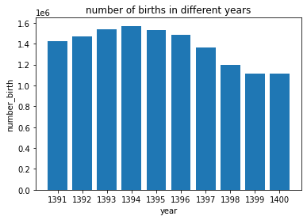

```python
labels = df_sum.columns
all_people = df_sum.loc['all',:]
x = np.arange(len(labels))
width = 0.35
fig, ax = plt.subplots()
rects = ax.bar(labels , all_people)
ax.set_ylabel('number_birth')
ax.set_xlabel('year')
ax.set_title('number of births in different years')
plt.show()
```

همانطور که در نمودار بالا می بینیم، میزان زاد و ولد به صورت کلی تا سال ۱۳۹۴ سیر صعودی داشته و پس از آن با شیب زیادی در حال کاهش است. و به نظر میرسد در آینده نزدیک نیز دوباره سیر صعودی پیدا نکند یعنی یا ثابت بماند و یا نزولی باشد.

##### **b. Total births divide by gender**

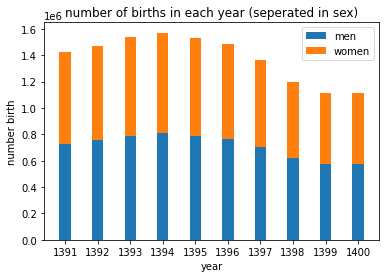

```python
labels = df_man.columns
width = 0.35
fig, ax = plt.subplots()

ax.bar(labels, man, width,label='men')
ax.bar(labels, woman, width,bottom=man, label='women')

ax.set_ylabel('number birth')
ax.set_title('number of births in each year (seperated in sex)')
ax.set_xlabel('year')
ax.legend()

plt.show()
```

در این قسمت نیز همانطور که می بینیم، نمودار کلی به همراه تقیسم جنسیتی در هر سال نمایش داده شده است. از نمودار بالا به نظر می رسد که میزان زاد و ولد در هر دو جنسیت تقریبا با یک شیب کم شده و یا افزایش یافته است. و در هر دو جنسیت بعد از سال ۱۳۹۴ نمودار نزولی شده است.

##### **c. Most births in last five years**

در این قسمت می خواهیم ۵ استان برتری را که در هر سال بیشترین تعداد تولد را داشته اند نمایش دهیم سپس همین کار را برای هر کدام از تک جنسیت ها نمایش خواهیم داد.

```python
try:
    connection = psycopg2.connect(user="postgres",
                                  password="admin",
                                  host= "localhost",
                                  port="5432",
                                  database="birthDB")

    cursor = connection.cursor()
    query_statement_men = """ SELECT ostan, SUM(_sum) AS sum_birth
    FROM public.iran_birth
    WHERE saal = 96
    GROUP BY ostan
    ORDER BY sum_birth DESC
    LIMIT 5
    """
    cursor.execute(query_statement_men)
    record = cursor.fetchall()
    birth_96 = record

    query_statement_men = """ SELECT ostan, SUM(_sum) AS sum_birth
    FROM public.iran_birth
    WHERE saal = 97
    GROUP BY ostan
    ORDER BY sum_birth DESC
    LIMIT 5
    """
    cursor.execute(query_statement_men)
    record = cursor.fetchall()
    birth_97 = record

    query_statement_men = """ SELECT ostan, SUM(_sum) AS sum_birth
    FROM public.iran_birth
    WHERE saal = 98
    GROUP BY ostan
    ORDER BY sum_birth DESC
    LIMIT 5
    """
    cursor.execute(query_statement_men)
    record = cursor.fetchall()
    birth_98 = record

    query_statement_men = """ SELECT ostan, SUM(_sum) AS sum_birth
    FROM public.iran_birth
    WHERE saal = 99
    GROUP BY ostan
    ORDER BY sum_birth DESC
    LIMIT 5
    """
    cursor.execute(query_statement_men)
    record = cursor.fetchall()
    birth_99 = record

    query_statement_men = """ SELECT ostan, SUM(_sum) AS sum_birth
    FROM public.iran_birth
    WHERE saal = 1400
    GROUP BY ostan
    ORDER BY sum_birth DESC
    LIMIT 5
    """
    cursor.execute(query_statement_men)
    record = cursor.fetchall()
    birth_1400 = record


    ########################################################

    query_statement_men = """ SELECT ostan, SUM(man) AS sum_birth
    FROM public.iran_birth
    WHERE saal = 96
    GROUP BY ostan
    ORDER BY sum_birth DESC
    LIMIT 5
    """
    cursor.execute(query_statement_men)
    record = cursor.fetchall()
    man_96 = record

    query_statement_men = """ SELECT ostan, SUM(man) AS sum_birth
    FROM public.iran_birth
    WHERE saal = 97
    GROUP BY ostan
    ORDER BY sum_birth DESC
    LIMIT 5
    """
    cursor.execute(query_statement_men)
    record = cursor.fetchall()
    man_97 = record

    query_statement_men = """ SELECT ostan, SUM(man) AS sum_birth
    FROM public.iran_birth
    WHERE saal = 98
    GROUP BY ostan
    ORDER BY sum_birth DESC
    LIMIT 5
    """
    cursor.execute(query_statement_men)
    record = cursor.fetchall()
    man_98 = record

    query_statement_men = """ SELECT ostan, SUM(man) AS sum_birth
    FROM public.iran_birth
    WHERE saal = 99
    GROUP BY ostan
    ORDER BY sum_birth DESC
    LIMIT 5
    """
    cursor.execute(query_statement_men)
    record = cursor.fetchall()
    man_99 = record

    query_statement_men = """ SELECT ostan, SUM(man) AS sum_birth
    FROM public.iran_birth
    WHERE saal = 1400
    GROUP BY ostan
    ORDER BY sum_birth DESC
    LIMIT 5
    """
    cursor.execute(query_statement_men)
    record = cursor.fetchall()
    man_1400 = record


#################################################################
    query_statement_men = """ SELECT ostan, SUM(woman) AS sum_birth
    FROM public.iran_birth
    WHERE saal = 96
    GROUP BY ostan
    ORDER BY sum_birth DESC
    LIMIT 5
    """
    cursor.execute(query_statement_men)
    record = cursor.fetchall()
    woman_96 = record

    query_statement_men = """ SELECT ostan, SUM(woman) AS sum_birth
    FROM public.iran_birth
    WHERE saal = 97
    GROUP BY ostan
    ORDER BY sum_birth DESC
    LIMIT 5
    """
    cursor.execute(query_statement_men)
    record = cursor.fetchall()
    woman_97 = record

    query_statement_men = """ SELECT ostan, SUM(woman) AS sum_birth
    FROM public.iran_birth
    WHERE saal = 98
    GROUP BY ostan
    ORDER BY sum_birth DESC
    LIMIT 5
    """
    cursor.execute(query_statement_men)
    record = cursor.fetchall()
    woman_98 = record

    query_statement_men = """ SELECT ostan, SUM(woman) AS sum_birth
    FROM public.iran_birth
    WHERE saal = 99
    GROUP BY ostan
    ORDER BY sum_birth DESC
    LIMIT 5
    """
    cursor.execute(query_statement_men)
    record = cursor.fetchall()
    woman_99 = record

    query_statement_men = """ SELECT ostan, SUM(woman) AS sum_birth
    FROM public.iran_birth
    WHERE saal = 1400
    GROUP BY ostan
    ORDER BY sum_birth DESC
    LIMIT 5
    """
    cursor.execute(query_statement_men)
    record = cursor.fetchall()
    woman_1400 = record



except (Exception, Error) as error:
    print("Error while connecting to PostgreSQL", error)
finally:
    if (connection):
        cursor.close()
        connection.close()
        print("PostgreSQL connection is closed")
```

```
PostgreSQL connection is closed
```

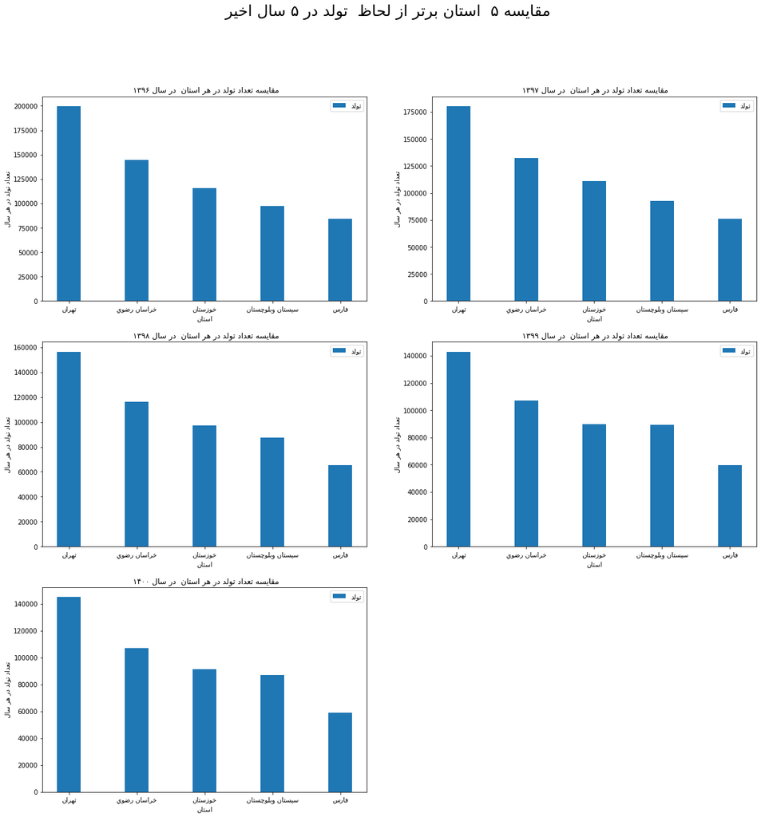

```python
from bidi.algorithm import get_display
import matplotlib.pyplot as plt
import arabic_reshaper
from arabic_reshaper import reshape

def to_persian(tex):
    reshaped_text = arabic_reshaper.reshape(tex)
    bidi_text = get_display(reshaped_text)
    return bidi_text

x_96 = [get_display(reshape(x[0])) for x in birth_96]
y_96 = [x[1] for x in birth_96]
#
x_97 = [get_display(reshape(x[0])) for x in birth_97]
y_97 = [x[1] for x in birth_97]
#
x_98 = [get_display(reshape(x[0])) for x in birth_98]
y_98 = [x[1] for x in birth_98]
#
x_99 = [get_display(reshape(x[0])) for x in birth_96]
y_99 = [x[1] for x in birth_99]
#
x_1400 = [get_display(reshape(x[0])) for x in birth_96]
y_1400 = [x[1] for x in birth_1400]

width = 0.35
fig, ax = plt.subplots(3,2,figsize = [20,20])
fig.delaxes(ax[2,1])
#
ax[0,0].bar(x_96, y_96, width,label=( to_persian(u'تولد')))
ax[0,0].set_ylabel( to_persian(u'تعداد تولد در هر سال'))
ax[0,0].set_title( to_persian(u'مقایسه تعداد تولد در هر استان  در سال ۱۳۹۶ '))
ax[0,0].set_xlabel( to_persian(u'استان'))
ax[0,0].legend()
#
ax[0,1].bar(x_97, y_97, width,label=( to_persian(u'تولد')))
ax[0,1].set_ylabel( to_persian(u'تعداد تولد در هر سال'))
ax[0,1].set_title( to_persian(u'مقایسه تعداد تولد در هر استان  در سال ۱۳۹۷ '))
ax[0,1].set_xlabel( to_persian(u'استان'))
ax[0,1].legend()
#
ax[1,0].bar(x_98, y_98, width,label=( to_persian(u'تولد')))
ax[1,0].set_ylabel( to_persian(u'تعداد تولد در هر سال'))
ax[1,0].set_title( to_persian(u'مقایسه تعداد تولد در هر استان  در سال ۱۳۹۸ '))
ax[1,0].set_xlabel( to_persian(u'استان'))
ax[1,0].legend()
#
ax[1,1].bar(x_99, y_99, width,label=( to_persian(u'تولد')))
ax[1,1].set_ylabel( to_persian(u'تعداد تولد در هر سال'))
ax[1,1].set_title( to_persian(u'مقایسه تعداد تولد در هر استان  در سال ۱۳۹۹ '))
ax[1,1].set_xlabel( to_persian(u'استان'))
ax[1,1].legend()
#
ax[2,0].bar(x_1400, y_1400, width,label=( to_persian(u'تولد')))
ax[2,0].set_ylabel( to_persian(u'تعداد تولد در هر سال'))
ax[2,0].set_title( to_persian(u'مقایسه تعداد تولد در هر استان  در سال ۱۴۰۰ '))
ax[2,0].set_xlabel( to_persian(u'استان'))
ax[2,0].legend()
fig.suptitle(to_persian(u'مقایسه ۵  استان برتر از لحاظ  تولد در ۵ سال اخیر')  ,size=24) # or plt.suptitle('Main title')

plt.show()
```

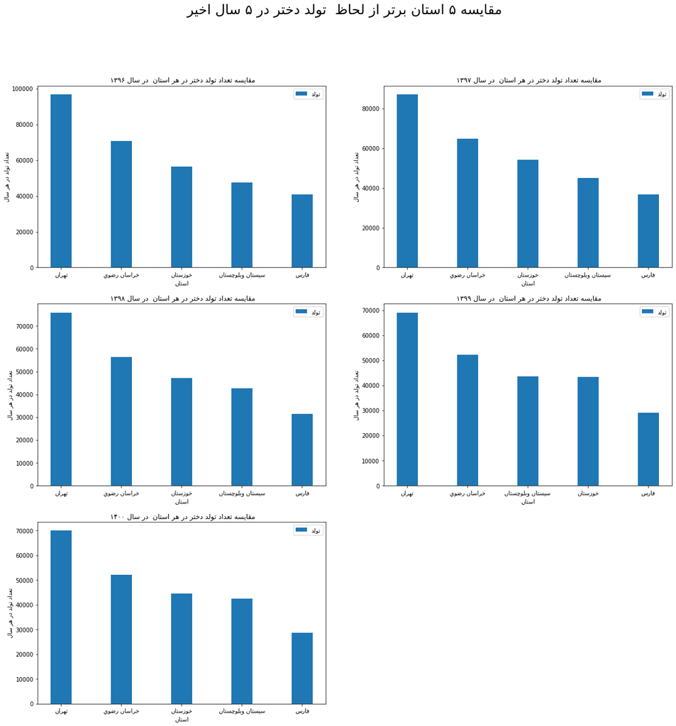

```python
x_96 = [get_display(reshape(x[0])) for x in woman_96] #pesky fix!
y_96 = [x[1] for x in woman_96]
#
x_97 = [get_display(reshape(x[0])) for x in woman_97] #pesky fix!
y_97 = [x[1] for x in woman_97]
#
x_98 = [get_display(reshape(x[0])) for x in woman_98] #pesky fix!
y_98 = [x[1] for x in woman_98]
#
x_99 = [get_display(reshape(x[0])) for x in woman_99] #pesky fix!
y_99 = [x[1] for x in woman_99]
#
x_1400 = [get_display(reshape(x[0])) for x in woman_1400] #pesky fix!
y_1400 = [x[1] for x in woman_1400]

width = 0.35       # the width of the bars: can also be len(x) sequence
fig, ax = plt.subplots(3,2,figsize = [20,20])
fig.delaxes(ax[2,1]) #The indexing is zero-based here
#
ax[0,0].bar(x_96, y_96, width,label=( to_persian(u'تولد')))
ax[0,0].set_ylabel( to_persian(u'تعداد تولد در هر سال'))
ax[0,0].set_title( to_persian(u'مقایسه تعداد تولد دختر در هر استان  در سال ۱۳۹۶ '))
ax[0,0].set_xlabel( to_persian(u'استان'))
ax[0,0].legend()
#
ax[0,1].bar(x_97, y_97, width,label=( to_persian(u'تولد')))
ax[0,1].set_ylabel( to_persian(u'تعداد تولد در هر سال'))
ax[0,1].set_title( to_persian(u'مقایسه تعداد تولد دختر در هر استان  در سال ۱۳۹۷ '))
ax[0,1].set_xlabel( to_persian(u'استان'))
ax[0,1].legend()
#
ax[1,0].bar(x_98, y_98, width,label=( to_persian(u'تولد')))
ax[1,0].set_ylabel( to_persian(u'تعداد تولد در هر سال'))
ax[1,0].set_title( to_persian(u'مقایسه تعداد تولد دختر در هر استان  در سال ۱۳۹۸ '))
ax[1,0].set_xlabel( to_persian(u'استان'))
ax[1,0].legend()
#
ax[1,1].bar(x_99, y_99, width,label=( to_persian(u'تولد')))
ax[1,1].set_ylabel( to_persian(u'تعداد تولد در هر سال'))
ax[1,1].set_title( to_persian(u'مقایسه تعداد تولد دختر در هر استان  در سال ۱۳۹۹ '))
ax[1,1].set_xlabel( to_persian(u'استان'))
ax[1,1].legend()
#
ax[2,0].bar(x_1400, y_1400, width,label=( to_persian(u'تولد')))
ax[2,0].set_ylabel( to_persian(u'تعداد تولد در هر سال'))
ax[2,0].set_title( to_persian(u'مقایسه تعداد تولد دختر در هر استان  در سال ۱۴۰۰ '))
ax[2,0].set_xlabel( to_persian(u'استان'))
ax[2,0].legend()
fig.suptitle(to_persian(u'مقایسه ۵ استان برتر از لحاظ  تولد دختر در ۵ سال اخیر')  ,size=24) # or plt.suptitle('Main title')

plt.show()
```

همانطور که از نمودار بالا معلوم است، ۵ استان برتر از لحاظ تعداد متولدین دختر در ۵ سال اخیر برعکس تعداد کلی متولدین عوض شده است یعنی در سال ۱۳۹۹ با اینکه تعداد کل متولیدن در خوزستان رتبه سوم را داشت، اما تعداد کل دختر های متولد در سیستان رتبه سوم را پیدا کرده و در تعداد متولدین دختر خوزستان چهارم است. نمودار ها تقریبا در هر سال به یک مقدار کاهشی بوده اند به این معنی که اگر سیر کلی کاهشی بوده است، سیر میزان تولد استانی نیز کاهشی بوده است.

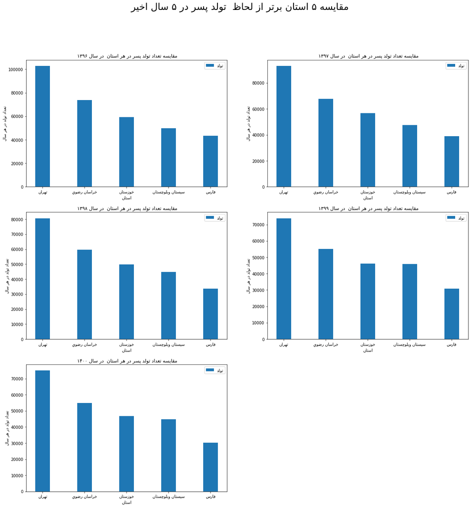

```python
x_96 = [get_display(reshape(x[0])) for x in man_96] #pesky fix!
y_96 = [x[1] for x in man_96]
#
x_97 = [get_display(reshape(x[0])) for x in man_97] #pesky fix!
y_97 = [x[1] for x in man_97]
#
x_98 = [get_display(reshape(x[0])) for x in man_98] #pesky fix!
y_98 = [x[1] for x in man_98]
#
x_99 = [get_display(reshape(x[0])) for x in man_96] #pesky fix!
y_99 = [x[1] for x in man_99]
#
x_1400 = [get_display(reshape(x[0])) for x in man_96] #pesky fix!
y_1400 = [x[1] for x in man_1400]

width = 0.35       # the width of the bars: can also be len(x) sequence
fig, ax = plt.subplots(3,2,figsize = [20,20])
fig.delaxes(ax[2,1]) #The indexing is zero-based here
#
ax[0,0].bar(x_96, y_96, width,label=( to_persian(u'تولد')))
ax[0,0].set_ylabel( to_persian(u'تعداد تولد در هر سال'))
ax[0,0].set_title( to_persian(u'مقایسه تعداد تولد پسر در هر استان  در سال ۱۳۹۶ '))
ax[0,0].set_xlabel( to_persian(u'استان'))
ax[0,0].legend()
#
ax[0,1].bar(x_97, y_97, width,label=( to_persian(u'تولد')))
ax[0,1].set_ylabel( to_persian(u'تعداد تولد در هر سال'))
ax[0,1].set_title( to_persian(u'مقایسه تعداد تولد پسر در هر استان  در سال ۱۳۹۷ '))
ax[0,1].set_xlabel( to_persian(u'استان'))
ax[0,1].legend()
#
ax[1,0].bar(x_98, y_98, width,label=( to_persian(u'تولد')))
ax[1,0].set_ylabel( to_persian(u'تعداد تولد در هر سال'))
ax[1,0].set_title( to_persian(u'مقایسه تعداد تولد پسر در هر استان  در سال ۱۳۹۸ '))
ax[1,0].set_xlabel( to_persian(u'استان'))
ax[1,0].legend()
#
ax[1,1].bar(x_99, y_99, width,label=( to_persian(u'تولد')))
ax[1,1].set_ylabel( to_persian(u'تعداد تولد در هر سال'))
ax[1,1].set_title( to_persian(u'مقایسه تعداد تولد پسر در هر استان  در سال ۱۳۹۹ '))
ax[1,1].set_xlabel( to_persian(u'استان'))
ax[1,1].legend()
#
ax[2,0].bar(x_1400, y_1400, width,label=( to_persian(u'تولد')))
ax[2,0].set_ylabel( to_persian(u'تعداد تولد در هر سال'))
ax[2,0].set_title( to_persian(u'مقایسه تعداد تولد پسر در هر استان  در سال ۱۴۰۰ '))
ax[2,0].set_xlabel( to_persian(u'استان'))
ax[2,0].legend()
fig.suptitle(to_persian(u'مقایسه ۵ استان برتر از لحاظ  تولد پسر در ۵ سال اخیر')  ,size=24) # or plt.suptitle('Main title')

plt.show()
```

##### **d. Least births in last five years**

```python
try:
    # Connect to an existing database
    connection = psycopg2.connect(user="postgres",
                                  password="admin",
                                  host= "localhost",
                                  port="5432",
                                  database="birthDB")

    # Create a cursor to perform database operations
    cursor = connection.cursor()
    # Executing a SQL query

    query_statement_men = """ SELECT ostan, SUM(_sum) AS sum_birth
    FROM public.iran_birth
    WHERE saal = 96
    GROUP BY ostan
    ORDER BY sum_birth ASC
    LIMIT 5
    """
    cursor.execute(query_statement_men)
    record = cursor.fetchall()
    birth_96 = record

    query_statement_men = """ SELECT ostan, SUM(_sum) AS sum_birth
    FROM public.iran_birth
    WHERE saal = 97
    GROUP BY ostan
    ORDER BY sum_birth ASC
    LIMIT 5
    """
    cursor.execute(query_statement_men)
    record = cursor.fetchall()
    birth_97 = record

    query_statement_men = """ SELECT ostan, SUM(_sum) AS sum_birth
    FROM public.iran_birth
    WHERE saal = 98
    GROUP BY ostan
    ORDER BY sum_birth ASC
    LIMIT 5
    """
    cursor.execute(query_statement_men)
    record = cursor.fetchall()
    birth_98 = record

    query_statement_men = """ SELECT ostan, SUM(_sum) AS sum_birth
    FROM public.iran_birth
    WHERE saal = 99
    GROUP BY ostan
    ORDER BY sum_birth ASC
    LIMIT 5
    """
    cursor.execute(query_statement_men)
    record = cursor.fetchall()
    birth_99 = record

    query_statement_men = """ SELECT ostan, SUM(_sum) AS sum_birth
    FROM public.iran_birth
    WHERE saal = 1400
    GROUP BY ostan
    ORDER BY sum_birth ASC
    LIMIT 5
    """
    cursor.execute(query_statement_men)
    record = cursor.fetchall()
    birth_1400 = record


    ########################################################

    query_statement_men = """ SELECT ostan, SUM(man) AS sum_birth
    FROM public.iran_birth
    WHERE saal = 96
    GROUP BY ostan
    ORDER BY sum_birth ASC
    LIMIT 5
    """
    cursor.execute(query_statement_men)
    record = cursor.fetchall()
    man_96 = record

    query_statement_men = """ SELECT ostan, SUM(man) AS sum_birth
    FROM public.iran_birth
    WHERE saal = 97
    GROUP BY ostan
    ORDER BY sum_birth ASC
    LIMIT 5
    """
    cursor.execute(query_statement_men)
    record = cursor.fetchall()
    man_97 = record

    query_statement_men = """ SELECT ostan, SUM(man) AS sum_birth
    FROM public.iran_birth
    WHERE saal = 98
    GROUP BY ostan
    ORDER BY sum_birth ASC
    LIMIT 5
    """
    cursor.execute(query_statement_men)
    record = cursor.fetchall()
    man_98 = record

    query_statement_men = """ SELECT ostan, SUM(man) AS sum_birth
    FROM public.iran_birth
    WHERE saal = 99
    GROUP BY ostan
    ORDER BY sum_birth ASC
    LIMIT 5
    """
    cursor.execute(query_statement_men)
    record = cursor.fetchall()
    man_99 = record

    query_statement_men = """ SELECT ostan, SUM(man) AS sum_birth
    FROM public.iran_birth
    WHERE saal = 1400
    GROUP BY ostan
    ORDER BY sum_birth ASC
    LIMIT 5
    """
    cursor.execute(query_statement_men)
    record = cursor.fetchall()
    man_1400 = record


#################################################################
    query_statement_men = """ SELECT ostan, SUM(woman) AS sum_birth
    FROM public.iran_birth
    WHERE saal = 96
    GROUP BY ostan
    ORDER BY sum_birth ASC
    LIMIT 5
    """
    cursor.execute(query_statement_men)
    record = cursor.fetchall()
    woman_96 = record

    query_statement_men = """ SELECT ostan, SUM(woman) AS sum_birth
    FROM public.iran_birth
    WHERE saal = 97
    GROUP BY ostan
    ORDER BY sum_birth ASC
    LIMIT 5
    """
    cursor.execute(query_statement_men)
    record = cursor.fetchall()
    woman_97 = record

    query_statement_men = """ SELECT ostan, SUM(woman) AS sum_birth
    FROM public.iran_birth
    WHERE saal = 98
    GROUP BY ostan
    ORDER BY sum_birth ASC
    LIMIT 5
    """
    cursor.execute(query_statement_men)
    record = cursor.fetchall()
    woman_98 = record

    query_statement_men = """ SELECT ostan, SUM(woman) AS sum_birth
    FROM public.iran_birth
    WHERE saal = 99
    GROUP BY ostan
    ORDER BY sum_birth ASC
    LIMIT 5
    """
    cursor.execute(query_statement_men)
    record = cursor.fetchall()
    woman_99 = record

    query_statement_men = """ SELECT ostan, SUM(woman) AS sum_birth
    FROM public.iran_birth
    WHERE saal = 1400
    GROUP BY ostan
    ORDER BY sum_birth ASC
    LIMIT 5
    """
    cursor.execute(query_statement_men)
    record = cursor.fetchall()
    woman_1400 = record



except (Exception, Error) as error:
    print("Error while connecting to PostgreSQL", error)
finally:
    if (connection):
        cursor.close()
        connection.close()
        print("PostgreSQL connection is closed")
```

```
PostgreSQL connection is closed
```

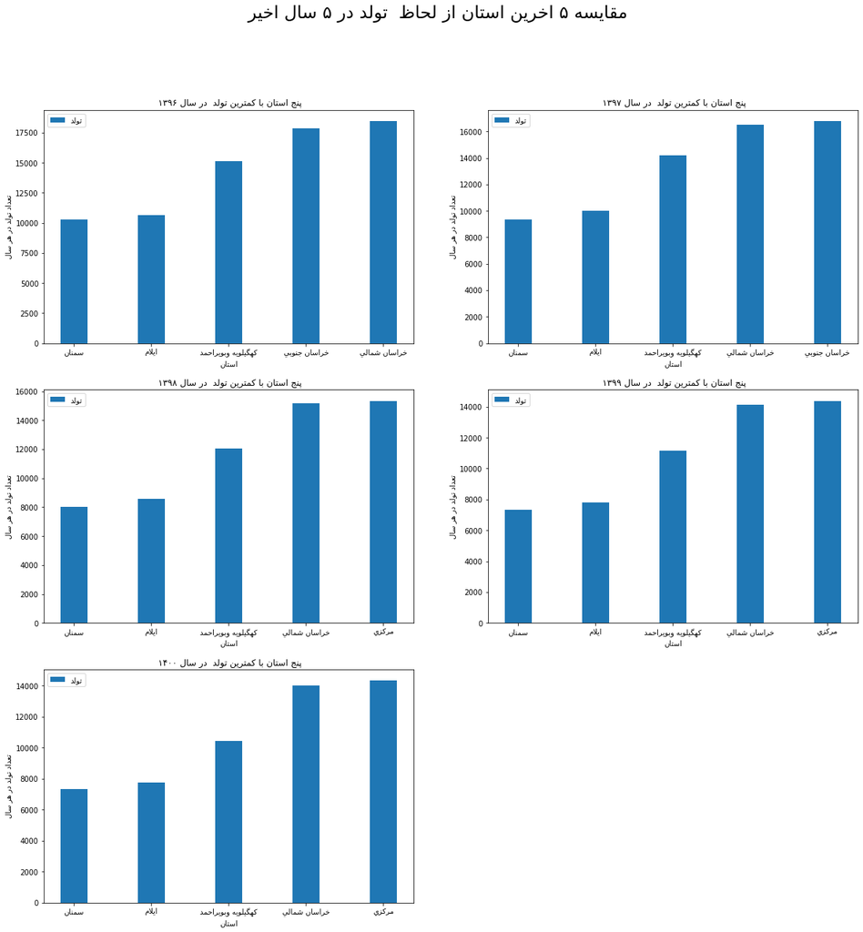

```python
from bidi.algorithm import get_display
import matplotlib.pyplot as plt
import arabic_reshaper
from arabic_reshaper import reshape

def to_persian(tex):
    reshaped_text = arabic_reshaper.reshape(tex)
    bidi_text = get_display(reshaped_text)
    return bidi_text

x_96 = [get_display(reshape(x[0])) for x in birth_96] #pesky fix!
y_96 = [x[1] for x in birth_96]
#
x_97 = [get_display(reshape(x[0])) for x in birth_97] #pesky fix!
y_97 = [x[1] for x in birth_97]
#
x_98 = [get_display(reshape(x[0])) for x in birth_98] #pesky fix!
y_98 = [x[1] for x in birth_98]
#
x_99 = [get_display(reshape(x[0])) for x in birth_99] #pesky fix!
y_99 = [x[1] for x in birth_99]
#
x_1400 = [get_display(reshape(x[0])) for x in birth_1400] #pesky fix!
y_1400 = [x[1] for x in birth_1400]

width = 0.35       # the width of the bars: can also be len(x) sequence
fig, ax = plt.subplots(3,2,figsize = [20,20])
fig.delaxes(ax[2,1]) #The indexing is zero-based here
#
ax[0,0].bar(x_96, y_96, width,label=( to_persian(u'تولد')))
ax[0,0].set_ylabel( to_persian(u'تعداد تولد در هر سال'))
ax[0,0].set_title( to_persian(u'پنج استان با کمترین تولد  در سال ۱۳۹۶ '))
ax[0,0].set_xlabel( to_persian(u'استان'))
ax[0,0].legend()
#
ax[0,1].bar(x_97, y_97, width,label=( to_persian(u'تولد')))
ax[0,1].set_ylabel( to_persian(u'تعداد تولد در هر سال'))
ax[0,1].set_title( to_persian(u'پنج استان با کمترین تولد  در سال ۱۳۹۷ '))
ax[0,1].set_xlabel( to_persian(u'استان'))
ax[0,1].legend()
#
ax[1,0].bar(x_98, y_98, width,label=( to_persian(u'تولد')))
ax[1,0].set_ylabel( to_persian(u'تعداد تولد در هر سال'))
ax[1,0].set_title( to_persian(u'پنج استان با کمترین تولد  در سال ۱۳۹۸ '))
ax[1,0].set_xlabel( to_persian(u'استان'))
ax[1,0].legend()
#
ax[1,1].bar(x_99, y_99, width,label=( to_persian(u'تولد')))
ax[1,1].set_ylabel( to_persian(u'تعداد تولد در هر سال'))
ax[1,1].set_title( to_persian(u'پنج استان با کمترین تولد  در سال ۱۳۹۹ '))
ax[1,1].set_xlabel( to_persian(u'استان'))
ax[1,1].legend()
#
ax[2,0].bar(x_1400, y_1400, width,label=( to_persian(u'تولد')))
ax[2,0].set_ylabel( to_persian(u'تعداد تولد در هر سال'))
ax[2,0].set_title( to_persian(u'پنج استان با کمترین تولد  در سال ۱۴۰۰ '))
ax[2,0].set_xlabel( to_persian(u'استان'))
ax[2,0].legend()
fig.suptitle(to_persian(u'مقایسه ۵ اخرین استان از لحاظ  تولد در ۵ سال اخیر')  ,size=24) # or plt.suptitle('Main title')

plt.show()
```

همانطور که در نمودار بالا می بینید ۵ استان از لحاظ کمترین میزان متولد در هر سال را مشاهده می کنیم. از سال ۹۸ استان ها ترتیب یکسانی در تعداد متولد ها دارند اما در سال های ۹۶ و ۹۷ ترتیب ها متفاوت است. در سال ۹۶ خراسان شمال رتبه پنجم را داشت که در سال های بعد به رتبه چهارم رسید. روند کلی کاهش میزان تولد در هر سال در این نمودار نیز قابل مشاهده می باشد.

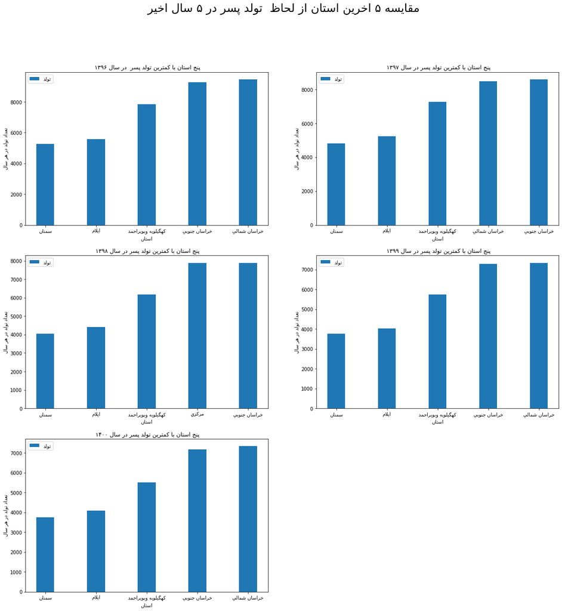

```python
x_96 = [get_display(reshape(x[0])) for x in man_96] #pesky fix!
y_96 = [x[1] for x in man_96]
#
x_97 = [get_display(reshape(x[0])) for x in man_97] #pesky fix!
y_97 = [x[1] for x in man_97]
#
x_98 = [get_display(reshape(x[0])) for x in man_98] #pesky fix!
y_98 = [x[1] for x in man_98]
#
x_99 = [get_display(reshape(x[0])) for x in man_96] #pesky fix!
y_99 = [x[1] for x in man_99]
#
x_1400 = [get_display(reshape(x[0])) for x in man_96] #pesky fix!
y_1400 = [x[1] for x in man_1400]

width = 0.35       # the width of the bars: can also be len(x) sequence
fig, ax = plt.subplots(3,2,figsize = [20,20])
fig.delaxes(ax[2,1]) #The indexing is zero-based here
#
ax[0,0].bar(x_96, y_96, width,label=( to_persian(u'تولد')))
ax[0,0].set_ylabel( to_persian(u'تعداد تولد در هر سال'))
ax[0,0].set_title( to_persian(u'پنج استان با کمترین تولد پسر  در سال ۱۳۹۶ '))
ax[0,0].set_xlabel( to_persian(u'استان'))
ax[0,0].legend()
#
ax[0,1].bar(x_97, y_97, width,label=( to_persian(u'تولد')))
ax[0,1].set_ylabel( to_persian(u'تعداد تولد در هر سال'))
ax[0,1].set_title( to_persian(u'پنج استان با کمترین تولد پسر در سال ۱۳۹۷ '))
ax[0,1].set_xlabel( to_persian(u'استان'))
ax[0,1].legend()
#
ax[1,0].bar(x_98, y_98, width,label=( to_persian(u'تولد')))
ax[1,0].set_ylabel( to_persian(u'تعداد تولد در هر سال'))
ax[1,0].set_title( to_persian(u'پنج استان با کمترین تولد پسر در سال ۱۳۹۸ '))
ax[1,0].set_xlabel( to_persian(u'استان'))
ax[1,0].legend()
#
ax[1,1].bar(x_99, y_99, width,label=( to_persian(u'تولد')))
ax[1,1].set_ylabel( to_persian(u'تعداد تولد در هر سال'))
ax[1,1].set_title( to_persian(u'پنج استان با کمترین تولد پسر در سال ۱۳۹۹ '))
ax[1,1].set_xlabel( to_persian(u'استان'))
ax[1,1].legend()
#
ax[2,0].bar(x_1400, y_1400, width,label=( to_persian(u'تولد')))
ax[2,0].set_ylabel( to_persian(u'تعداد تولد در هر سال'))
ax[2,0].set_title( to_persian(u'پنج استان با کمترین تولد پسر در سال ۱۴۰۰ '))
ax[2,0].set_xlabel( to_persian(u'استان'))
ax[2,0].legend()
fig.suptitle(to_persian(u'مقایسه ۵ اخرین استان از لحاظ  تولد پسر در ۵ سال اخیر')  ,size=24) # or plt.suptitle('Main title')

plt.show()
```

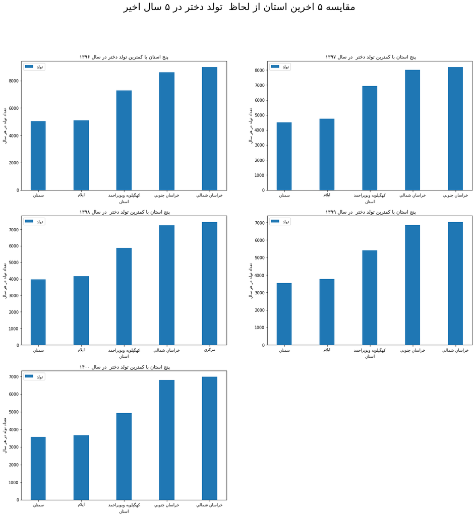

```python
x_96 = [get_display(reshape(x[0])) for x in woman_96] #pesky fix!
y_96 = [x[1] for x in woman_96]
#
x_97 = [get_display(reshape(x[0])) for x in woman_97] #pesky fix!
y_97 = [x[1] for x in woman_97]
#
x_98 = [get_display(reshape(x[0])) for x in woman_98] #pesky fix!
y_98 = [x[1] for x in woman_98]
#
x_99 = [get_display(reshape(x[0])) for x in woman_96] #pesky fix!
y_99 = [x[1] for x in woman_99]
#
x_1400 = [get_display(reshape(x[0])) for x in woman_96] #pesky fix!
y_1400 = [x[1] for x in woman_1400]

width = 0.35       # the width of the bars: can also be len(x) sequence
fig, ax = plt.subplots(3,2,figsize = [20,20])
fig.delaxes(ax[2,1]) #The indexing is zero-based here
#
ax[0,0].bar(x_96, y_96, width,label=( to_persian(u'تولد')))
ax[0,0].set_ylabel( to_persian(u'تعداد تولد در هر سال'))
ax[0,0].set_title( to_persian(u' پنج استان با کمترین تولد دختر در سال ۱۳۹۶ '))
ax[0,0].set_xlabel( to_persian(u'استان'))
ax[0,0].legend()
#
ax[0,1].bar(x_97, y_97, width,label=( to_persian(u'تولد')))
ax[0,1].set_ylabel( to_persian(u'تعداد تولد در هر سال'))
ax[0,1].set_title( to_persian(u'پنج استان با کمترین تولد دختر  در سال ۱۳۹۷ '))
ax[0,1].set_xlabel( to_persian(u'استان'))
ax[0,1].legend()
#
ax[1,0].bar(x_98, y_98, width,label=( to_persian(u'تولد')))
ax[1,0].set_ylabel( to_persian(u'تعداد تولد در هر سال'))
ax[1,0].set_title( to_persian(u'پنج استان با کمترین تولد دختر  در سال ۱۳۹۸ '))
ax[1,0].set_xlabel( to_persian(u'استان'))
ax[1,0].legend()
#
ax[1,1].bar(x_99, y_99, width,label=( to_persian(u'تولد')))
ax[1,1].set_ylabel( to_persian(u'تعداد تولد در هر سال'))
ax[1,1].set_title( to_persian(u'پنج استان با کمترین تولد دختر  در سال ۱۳۹۹ '))
ax[1,1].set_xlabel( to_persian(u'استان'))
ax[1,1].legend()
#
ax[2,0].bar(x_1400, y_1400, width,label=( to_persian(u'تولد')))
ax[2,0].set_ylabel( to_persian(u'تعداد تولد در هر سال'))
ax[2,0].set_title( to_persian(u'پنج استان با کمترین تولد دختر  در سال ۱۴۰۰ '))
ax[2,0].set_xlabel( to_persian(u'استان'))
ax[2,0].legend()
fig.suptitle(to_persian(u'مقایسه ۵ اخرین استان از لحاظ  تولد دختر در ۵ سال اخیر')  ,size=24) # or plt.suptitle('Main title')

plt.show()
```

نمودار تعداد تولد دختر ها در هر سال نیز مانند نمودار های قبلی از ترتیب کاهشی میزان تولد در هر سال پیروی می کند و مانند بخش قبلی سمام، ایلام و کهگلویه کمترین میزان متولد را در هر سال دارند.

##### **e. Most Birth-rate**

در این قسمت می خواهیم نرخ ولادت ها را استخراج کنیم. برای این کار برعکس مرحله قبل که فقط ۵ استان برتر را خروجی می گرفتیم، در اینجا میزان متولدین تمامی استان ها را در query خواسته شده بدست می آوریم. سپس یک دیتافریم از تعداد متولدین در هر استان در آن سال تولید می کنیم. در ادامه این دیتافریم را با دیتافریم ساخته شده از فایل Iran_poplulations.csv ادغام میکنیم. برای اینکه دو دیتاست را با هم ادغام کنیم تابعی نوشتیم که فرمت ی و ک ها را به فرمت استاندارد در بیاورد. پس از ادغام دو دیتافریم برای هر سال، یک ستون به نام ستون nesbat می سازیم که حاصل تقسیم میزان متولدین در هر سال به نسبت جمعیت آن استان می باشد. سپس این ستون را مرتب کرده و در ادامه آن را پلات می کنیم. برای اینکه در کتابخانه matplotlib بتوانیم فارسی را نمایش دهیم تابعی به نام to_persian نوشتیم که کلمات را به فرمت قابل نشان دادن در matplotlib در می اورد. در در این قسمت نمودار های ۵ استان دارای بیشترین نرخ تولد را به ازای هر سال نمایش می دهیم و این کار را برای جنسیت های مرد و زن نیز انجام خواهیم داد.

```python
try:
    # Connect to an existing database
    connection = psycopg2.connect(user="postgres",
                                  password="admin",
                                  host= "localhost",
                                  port="5432",
                                  database="birthDB")

    # Create a cursor to perform database operations
    cursor = connection.cursor()
    # Executing a SQL query

    query_statement_men = """ SELECT ostan, SUM(_sum) AS sum_birth
    FROM public.iran_birth
    WHERE saal = 96
    GROUP BY ostan
    ORDER BY sum_birth ASC
    """
    cursor.execute(query_statement_men)
    record = cursor.fetchall()
    birth_96 = record

    query_statement_men = """ SELECT ostan, SUM(_sum) AS sum_birth
    FROM public.iran_birth
    WHERE saal = 97
    GROUP BY ostan
    ORDER BY sum_birth ASC
    """
    cursor.execute(query_statement_men)
    record = cursor.fetchall()
    birth_97 = record

    query_statement_men = """ SELECT ostan, SUM(_sum) AS sum_birth
    FROM public.iran_birth
    WHERE saal = 98
    GROUP BY ostan
    ORDER BY sum_birth ASC
    """
    cursor.execute(query_statement_men)
    record = cursor.fetchall()
    birth_98 = record

    query_statement_men = """ SELECT ostan, SUM(_sum) AS sum_birth
    FROM public.iran_birth
    WHERE saal = 99
    GROUP BY ostan
    ORDER BY sum_birth ASC
    """
    cursor.execute(query_statement_men)
    record = cursor.fetchall()
    birth_99 = record

    query_statement_men = """ SELECT ostan, SUM(_sum) AS sum_birth
    FROM public.iran_birth
    WHERE saal = 1400
    GROUP BY ostan
    ORDER BY sum_birth ASC
    """
    cursor.execute(query_statement_men)
    record = cursor.fetchall()
    birth_1400 = record


    ########################################################

    query_statement_men = """ SELECT ostan, SUM(man) AS sum_birth
    FROM public.iran_birth
    WHERE saal = 96
    GROUP BY ostan
    ORDER BY sum_birth ASC
    """
    cursor.execute(query_statement_men)
    record = cursor.fetchall()
    man_96 = record

    query_statement_men = """ SELECT ostan, SUM(man) AS sum_birth
    FROM public.iran_birth
    WHERE saal = 97
    GROUP BY ostan
    ORDER BY sum_birth ASC
    """
    cursor.execute(query_statement_men)
    record = cursor.fetchall()
    man_97 = record

    query_statement_men = """ SELECT ostan, SUM(man) AS sum_birth
    FROM public.iran_birth
    WHERE saal = 98
    GROUP BY ostan
    ORDER BY sum_birth ASC
    """
    cursor.execute(query_statement_men)
    record = cursor.fetchall()
    man_98 = record

    query_statement_men = """ SELECT ostan, SUM(man) AS sum_birth
    FROM public.iran_birth
    WHERE saal = 99
    GROUP BY ostan
    ORDER BY sum_birth ASC
    """
    cursor.execute(query_statement_men)
    record = cursor.fetchall()
    man_99 = record

    query_statement_men = """ SELECT ostan, SUM(man) AS sum_birth
    FROM public.iran_birth
    WHERE saal = 1400
    GROUP BY ostan
    ORDER BY sum_birth ASC
    """
    cursor.execute(query_statement_men)
    record = cursor.fetchall()
    man_1400 = record


#################################################################
    query_statement_men = """ SELECT ostan, SUM(woman) AS sum_birth
    FROM public.iran_birth
    WHERE saal = 96
    GROUP BY ostan
    ORDER BY sum_birth ASC
    """
    cursor.execute(query_statement_men)
    record = cursor.fetchall()
    woman_96 = record

    query_statement_men = """ SELECT ostan, SUM(woman) AS sum_birth
    FROM public.iran_birth
    WHERE saal = 97
    GROUP BY ostan
    ORDER BY sum_birth ASC
    """
    cursor.execute(query_statement_men)
    record = cursor.fetchall()
    woman_97 = record

    query_statement_men = """ SELECT ostan, SUM(woman) AS sum_birth
    FROM public.iran_birth
    WHERE saal = 98
    GROUP BY ostan
    ORDER BY sum_birth ASC
    """
    cursor.execute(query_statement_men)
    record = cursor.fetchall()
    woman_98 = record

    query_statement_men = """ SELECT ostan, SUM(woman) AS sum_birth
    FROM public.iran_birth
    WHERE saal = 99
    GROUP BY ostan
    ORDER BY sum_birth ASC
    """
    cursor.execute(query_statement_men)
    record = cursor.fetchall()
    woman_99 = record

    query_statement_men = """ SELECT ostan, SUM(woman) AS sum_birth
    FROM public.iran_birth
    WHERE saal = 1400
    GROUP BY ostan
    ORDER BY sum_birth ASC
    """
    cursor.execute(query_statement_men)
    record = cursor.fetchall()
    woman_1400 = record



except (Exception, Error) as error:
    print("Error while connecting to PostgreSQL", error)
finally:
    if (connection):
        cursor.close()
        connection.close()
        print("PostgreSQL connection is closed")
```

```
PostgreSQL connection is closed
```

```python
x_96 = [get_display(reshape(x[0])) for x in birth_96]
y_96 = [x[1] for x in birth_96]
#
x_97 = [get_display(reshape(x[0])) for x in birth_97]
y_97 = [x[1] for x in birth_97]
#
x_98 = [get_display(reshape(x[0])) for x in birth_98]
y_98 = [x[1] for x in birth_98]
#
x_99 = [get_display(reshape(x[0])) for x in birth_99]
y_99 = [x[1] for x in birth_99]
#
x_1400 = [get_display(reshape(x[0])) for x in birth_1400]
y_1400 = [x[1] for x in birth_1400]
```

```python
def regularize_unicode(s):
    s=s.str.replace('ک','ك')
    s=s.str.replace('ی','ي')
    s=s.str.replace(chr(8204),'')
    return s

def make_df_of_rate(df_popu,birth ):
## df of birth of all men
    df_birth = pd.DataFrame(birth,columns=['ostan','birth'])
    df_popu['ostan'] = regularize_unicode(df_popu['ostan'])
    df_birth['ostan'] = regularize_unicode(df_birth['ostan'])
    _df = pd.merge(df_birth, df_popu, on='ostan',how='outer')
    _df['nesbat'] = _df['birth']  /_df['Population']
    _df = _df.sort_values(by=['nesbat'],ascending=False).reset_index(drop = True)
    _df['ostan'] = [get_display(reshape(x)) for x in _df['ostan']]
    return _df

addrs = './Datasets/Part1/Iran_population.csv'
df_popu = pd.read_csv(addrs)
df_popu.set_axis(['ostan', 'Population'], axis=1, inplace=True)
```

```python
df_rate_96 = make_df_of_rate(df_popu,birth_96)
df_rate_97 = make_df_of_rate(df_popu,birth_97)
df_rate_98 = make_df_of_rate(df_popu,birth_98)
df_rate_99 = make_df_of_rate(df_popu,birth_99)
df_rate_1400 = make_df_of_rate(df_popu,birth_1400)
```

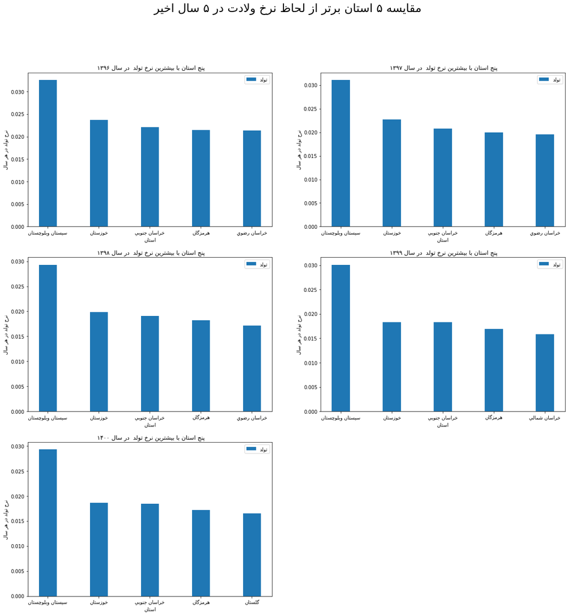

```python
width = 0.35       # the width of the bars: can also be len(x) sequence
fig, ax = plt.subplots(3,2,figsize = [20,20])
fig.delaxes(ax[2,1]) #The indexing is zero-based here
#
ax[0,0].bar(df_rate_96['ostan'].head(5), df_rate_96['nesbat'].head(5), width,label=( to_persian(u'تولد')))
ax[0,0].set_ylabel( to_persian(u'نرخ تولد در هر سال'))
ax[0,0].set_title( to_persian(u'پنج استان با بیشترین نرخ تولد  در سال ۱۳۹۶ '))
ax[0,0].set_xlabel( to_persian(u'استان'))
ax[0,0].legend()
#
ax[0,1].bar(df_rate_97['ostan'].head(5), df_rate_97['nesbat'].head(5), width,label=( to_persian(u'تولد')))
ax[0,1].set_ylabel( to_persian(u'نرخ تولد در هر سال'))
ax[0,1].set_title( to_persian(u'پنج استان با بیشترین نرخ تولد  در سال ۱۳۹۷ '))
ax[0,1].set_xlabel( to_persian(u'استان'))
ax[0,1].legend()
#
ax[1,0].bar(df_rate_98['ostan'].head(5), df_rate_98['nesbat'].head(5), width,label=( to_persian(u'تولد')))
ax[1,0].set_ylabel( to_persian(u'نرخ تولد در هر سال'))
ax[1,0].set_title( to_persian(u'پنج استان با بیشترین نرخ تولد  در سال ۱۳۹۸ '))
ax[1,0].set_xlabel( to_persian(u'استان'))
ax[1,0].legend()
#
ax[1,1].bar(df_rate_99['ostan'].head(5), df_rate_99['nesbat'].head(5), width,label=( to_persian(u'تولد')))
ax[1,1].set_ylabel( to_persian(u'نرخ تولد در هر سال'))
ax[1,1].set_title( to_persian(u'پنج استان با بیشترین نرخ تولد  در سال ۱۳۹۹ '))
ax[1,1].set_xlabel( to_persian(u'استان'))
ax[1,1].legend()
#
ax[2,0].bar(df_rate_1400['ostan'].head(5), df_rate_1400['nesbat'].head(5), width,label=( to_persian(u'تولد')))
ax[2,0].set_ylabel( to_persian(u'نرخ تولد در هر سال'))
ax[2,0].set_title( to_persian(u'پنج استان با بیشترین نرخ تولد  در سال ۱۴۰۰ '))
ax[2,0].set_xlabel( to_persian(u'استان'))
ax[2,0].legend()
fig.suptitle(to_persian(u'مقایسه ۵ استان برتر از لحاظ نرخ ولادت در ۵ سال اخیر')  ,size=24) # or plt.suptitle('Main title')
plt.show()
```

```python
df_rate_96 = make_df_of_rate(df_popu,man_96)
df_rate_97 = make_df_of_rate(df_popu,man_97)
df_rate_98 = make_df_of_rate(df_popu,man_98)
df_rate_99 = make_df_of_rate(df_popu,man_99)
df_rate_1400 = make_df_of_rate(df_popu,man_1400)
```

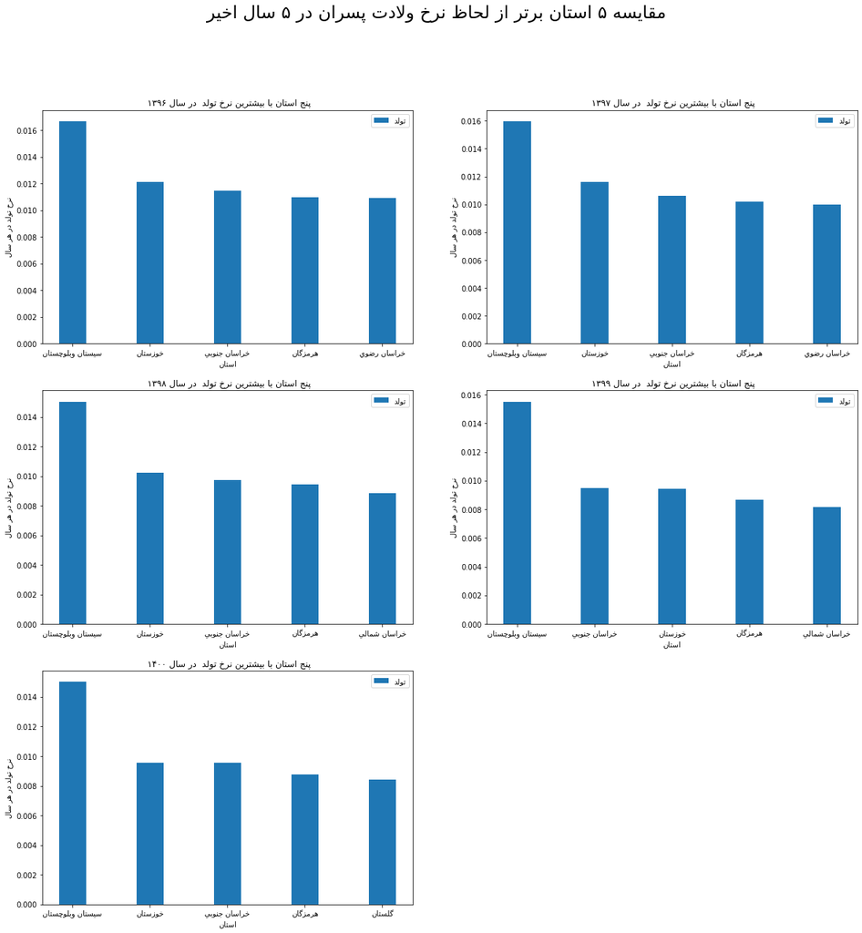

```python
width = 0.35
fig, ax = plt.subplots(3,2,figsize = [20,20])
fig.delaxes(ax[2,1])
#
ax[0,0].bar(df_rate_96['ostan'].head(5), df_rate_96['nesbat'].head(5), width,label=( to_persian(u'تولد')))
ax[0,0].set_ylabel( to_persian(u'نرخ تولد در هر سال'))
ax[0,0].set_title( to_persian(u'پنج استان با بیشترین نرخ تولد  در سال ۱۳۹۶ '))
ax[0,0].set_xlabel( to_persian(u'استان'))
ax[0,0].legend()
#
ax[0,1].bar(df_rate_97['ostan'].head(5), df_rate_97['nesbat'].head(5), width,label=( to_persian(u'تولد')))
ax[0,1].set_ylabel( to_persian(u'نرخ تولد در هر سال'))
ax[0,1].set_title( to_persian(u'پنج استان با بیشترین نرخ تولد  در سال ۱۳۹۷ '))
ax[0,1].set_xlabel( to_persian(u'استان'))
ax[0,1].legend()
#
ax[1,0].bar(df_rate_98['ostan'].head(5), df_rate_98['nesbat'].head(5), width,label=( to_persian(u'تولد')))
ax[1,0].set_ylabel( to_persian(u'نرخ تولد در هر سال'))
ax[1,0].set_title( to_persian(u'پنج استان با بیشترین نرخ تولد  در سال ۱۳۹۸ '))
ax[1,0].set_xlabel( to_persian(u'استان'))
ax[1,0].legend()
#
ax[1,1].bar(df_rate_99['ostan'].head(5), df_rate_99['nesbat'].head(5), width,label=( to_persian(u'تولد')))
ax[1,1].set_ylabel( to_persian(u'نرخ تولد در هر سال'))
ax[1,1].set_title( to_persian(u'پنج استان با بیشترین نرخ تولد  در سال ۱۳۹۹ '))
ax[1,1].set_xlabel( to_persian(u'استان'))
ax[1,1].legend()
#
ax[2,0].bar(df_rate_1400['ostan'].head(5), df_rate_1400['nesbat'].head(5), width,label=( to_persian(u'تولد')))
ax[2,0].set_ylabel( to_persian(u'نرخ تولد در هر سال'))
ax[2,0].set_title( to_persian(u'پنج استان با بیشترین نرخ تولد  در سال ۱۴۰۰ '))
ax[2,0].set_xlabel( to_persian(u'استان'))
ax[2,0].legend()
fig.suptitle(to_persian(u'مقایسه ۵ استان برتر از لحاظ نرخ ولادت پسران در ۵ سال اخیر')  ,size=24) # or plt.suptitle('Main title')
plt.show()
```

در این شکل نیز تقریبا تمامی ویژگی های گفته شده برای نمودار کلی را دارد با این تفاوت که در سال ۹۹ خوزستان دومین نرخ تولد را از دست داده است و خراسان جنوبی جای آن را گرفته است. در بقیه ویژگی ها این نمودار شبیه به نمودار قبلی می باشد.

```python
df_rate_96 = make_df_of_rate(df_popu,woman_96)
df_rate_97 = make_df_of_rate(df_popu,woman_97)
df_rate_98 = make_df_of_rate(df_popu,woman_98)
df_rate_99 = make_df_of_rate(df_popu,woman_99)
df_rate_1400 = make_df_of_rate(df_popu,woman_1400)
```

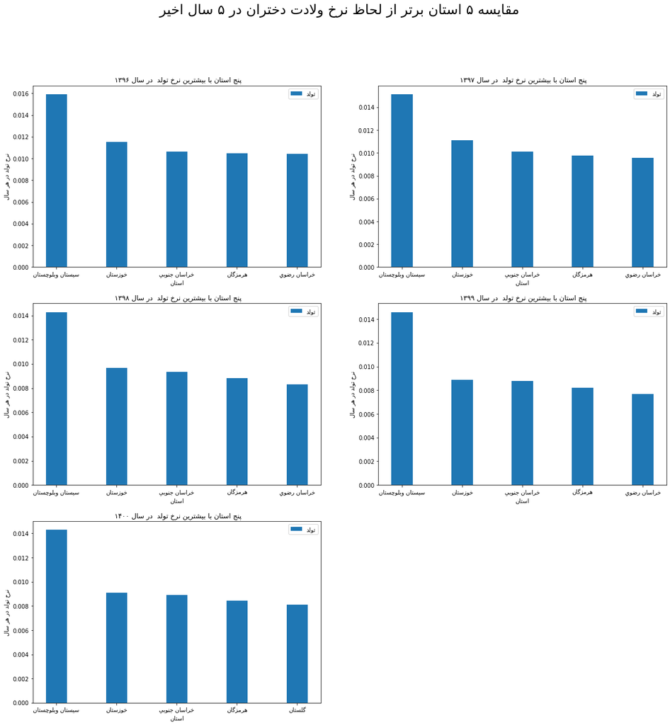

```python
width = 0.35       # the width of the bars: can also be len(x) sequence
fig, ax = plt.subplots(3,2,figsize = [20,20])
fig.delaxes(ax[2,1]) #The indexing is zero-based here
#
ax[0,0].bar(df_rate_96['ostan'].head(5), df_rate_96['nesbat'].head(5), width,label=( to_persian(u'تولد')))
ax[0,0].set_ylabel( to_persian(u'نرخ تولد در هر سال'))
ax[0,0].set_title( to_persian(u'پنج استان با بیشترین نرخ تولد  در سال ۱۳۹۶ '))
ax[0,0].set_xlabel( to_persian(u'استان'))
ax[0,0].legend()
#
ax[0,1].bar(df_rate_97['ostan'].head(5), df_rate_97['nesbat'].head(5), width,label=( to_persian(u'تولد')))
ax[0,1].set_ylabel( to_persian(u'نرخ تولد در هر سال'))
ax[0,1].set_title( to_persian(u'پنج استان با بیشترین نرخ تولد  در سال ۱۳۹۷ '))
ax[0,1].set_xlabel( to_persian(u'استان'))
ax[0,1].legend()
#
ax[1,0].bar(df_rate_98['ostan'].head(5), df_rate_98['nesbat'].head(5), width,label=( to_persian(u'تولد')))
ax[1,0].set_ylabel( to_persian(u'نرخ تولد در هر سال'))
ax[1,0].set_title( to_persian(u'پنج استان با بیشترین نرخ تولد  در سال ۱۳۹۸ '))
ax[1,0].set_xlabel( to_persian(u'استان'))
ax[1,0].legend()
#
ax[1,1].bar(df_rate_99['ostan'].head(5), df_rate_99['nesbat'].head(5), width,label=( to_persian(u'تولد')))
ax[1,1].set_ylabel( to_persian(u'نرخ تولد در هر سال'))
ax[1,1].set_title( to_persian(u'پنج استان با بیشترین نرخ تولد  در سال ۱۳۹۹ '))
ax[1,1].set_xlabel( to_persian(u'استان'))
ax[1,1].legend()
#
ax[2,0].bar(df_rate_1400['ostan'].head(5), df_rate_1400['nesbat'].head(5), width,label=( to_persian(u'تولد')))
ax[2,0].set_ylabel( to_persian(u'نرخ تولد در هر سال'))
ax[2,0].set_title( to_persian(u'پنج استان با بیشترین نرخ تولد  در سال ۱۴۰۰ '))
ax[2,0].set_xlabel( to_persian(u'استان'))
ax[2,0].legend()
fig.suptitle(to_persian(u'مقایسه ۵ استان برتر از لحاظ نرخ ولادت دختران در ۵ سال اخیر')  ,size=24) # or plt.suptitle('Main title')
plt.show()
```

ویژگی های این نمودار تقریبا شبیه نمودار نرخ متولدین کلی است و در تمامی موارد از آن پیروی می کند.

##### **f. Least Birth-rate**

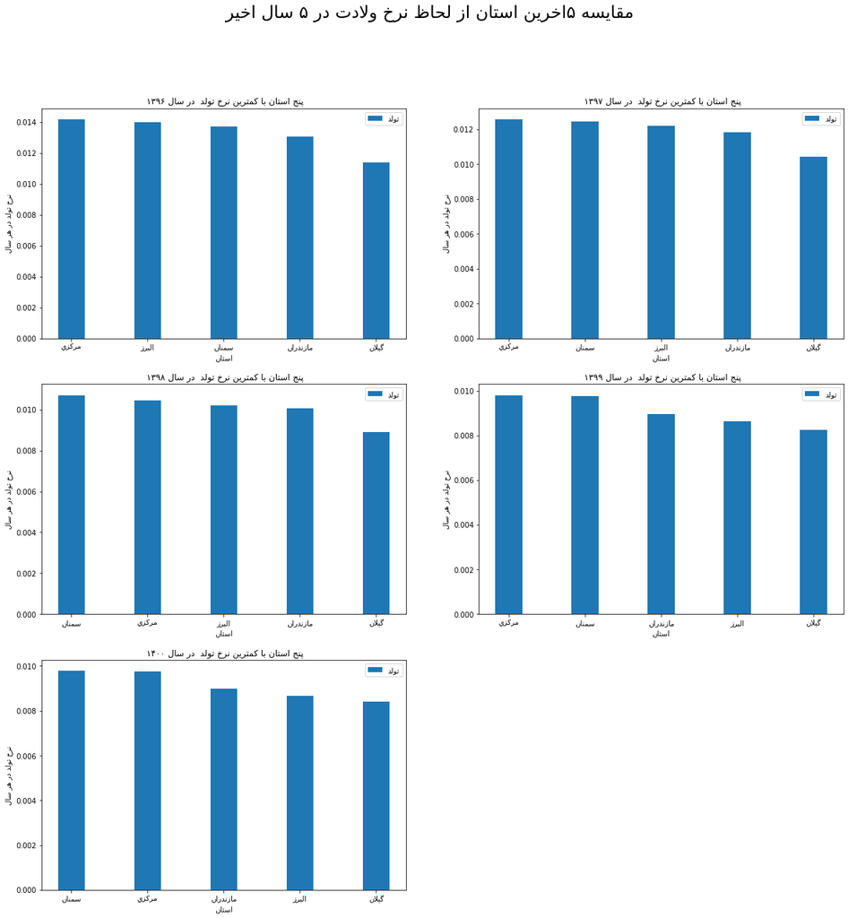

```python
df_rate_96 = make_df_of_rate(df_popu,birth_96)
df_rate_97 = make_df_of_rate(df_popu,birth_97)
df_rate_98 = make_df_of_rate(df_popu,birth_98)
df_rate_99 = make_df_of_rate(df_popu,birth_99)
df_rate_1400 = make_df_of_rate(df_popu,birth_1400)


width = 0.35       # the width of the bars: can also be len(x) sequence
fig, ax = plt.subplots(3,2,figsize = [20,20])
fig.delaxes(ax[2,1]) #The indexing is zero-based here
#
ax[0,0].bar(df_rate_96['ostan'].tail(5), df_rate_96['nesbat'].tail(5), width,label=( to_persian(u'تولد')))
ax[0,0].set_ylabel( to_persian(u'نرخ تولد در هر سال'))
ax[0,0].set_title( to_persian(u'پنج استان با کمترین نرخ تولد  در سال ۱۳۹۶ '))
ax[0,0].set_xlabel( to_persian(u'استان'))
ax[0,0].legend()
#
ax[0,1].bar(df_rate_97['ostan'].tail(5), df_rate_97['nesbat'].tail(5), width,label=( to_persian(u'تولد')))
ax[0,1].set_ylabel( to_persian(u'نرخ تولد در هر سال'))
ax[0,1].set_title( to_persian(u'پنج استان با کمترین نرخ تولد  در سال ۱۳۹۷ '))
ax[0,1].set_xlabel( to_persian(u'استان'))
ax[0,1].legend()
#
ax[1,0].bar(df_rate_98['ostan'].tail(5), df_rate_98['nesbat'].tail(5), width,label=( to_persian(u'تولد')))
ax[1,0].set_ylabel( to_persian(u'نرخ تولد در هر سال'))
ax[1,0].set_title( to_persian(u'پنج استان با کمترین نرخ تولد  در سال ۱۳۹۸ '))
ax[1,0].set_xlabel( to_persian(u'استان'))
ax[1,0].legend()
#
ax[1,1].bar(df_rate_99['ostan'].tail(5), df_rate_99['nesbat'].tail(5), width,label=( to_persian(u'تولد')))
ax[1,1].set_ylabel( to_persian(u'نرخ تولد در هر سال'))
ax[1,1].set_title( to_persian(u'پنج استان با کمترین نرخ تولد  در سال ۱۳۹۹ '))
ax[1,1].set_xlabel( to_persian(u'استان'))
ax[1,1].legend()
#
ax[2,0].bar(df_rate_1400['ostan'].tail(5), df_rate_1400['nesbat'].tail(5), width,label=( to_persian(u'تولد')))
ax[2,0].set_ylabel( to_persian(u'نرخ تولد در هر سال'))
ax[2,0].set_title( to_persian(u'پنج استان با کمترین نرخ تولد  در سال ۱۴۰۰ '))
ax[2,0].set_xlabel( to_persian(u'استان'))
ax[2,0].legend()
fig.suptitle(to_persian(u'مقایسه ۵اخرین استان از لحاظ نرخ ولادت در ۵ سال اخیر')  ,size=24) # or plt.suptitle('Main title')
plt.show()
```

در این قسمت به مقایسه ۵ استانی که کمترین نرخ تولد را دارند می پردازیم. همانطور که میبینیم گیلان در همه سال ها کمترین نرخ تولد را دارد. و پس از آن در سه سال اول مازندران کمترین نرخ فرزند آوری را داشته و سپس در دو سال اخیر البرز جای آن را گرفته است. همچنین از نمودار قابل فهم است که ۵ استان در تمامی سال ها ثابت هستند و کمترین نرخ فرزند آوری را دارند.

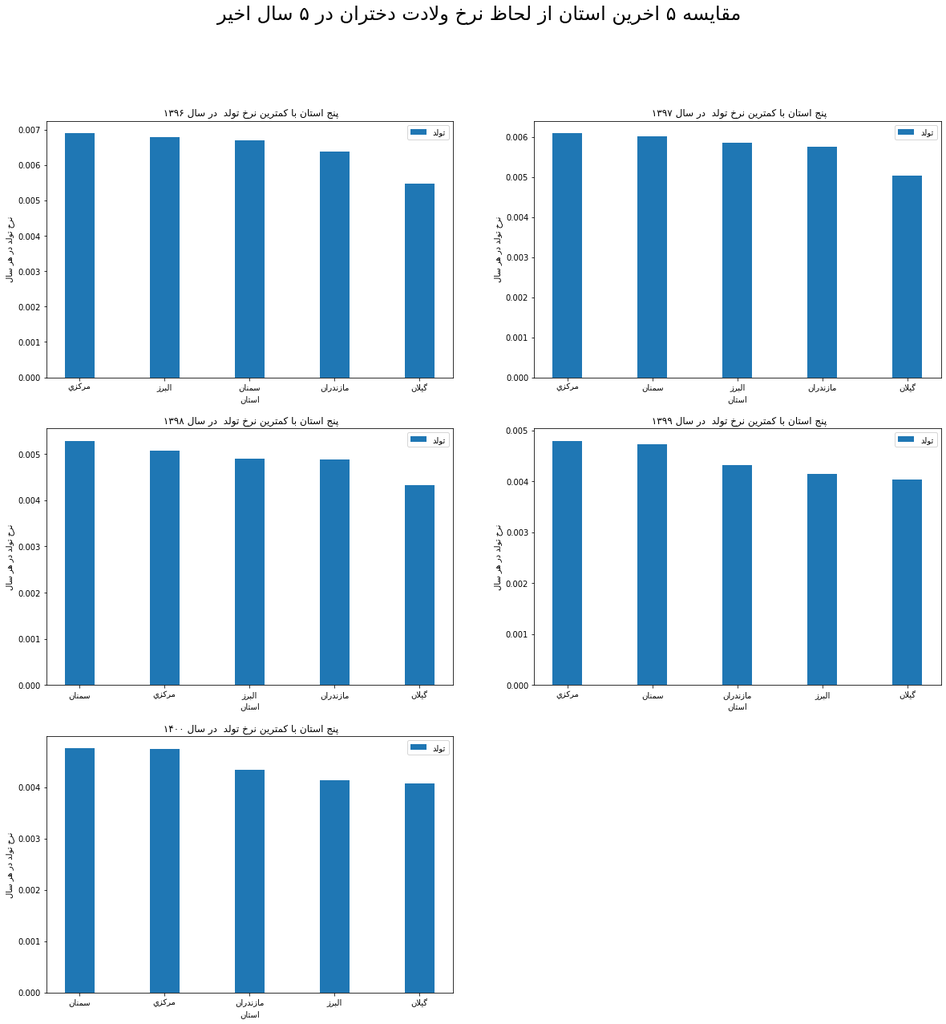

```python
df_rate_96 = make_df_of_rate(df_popu,woman_96)
df_rate_97 = make_df_of_rate(df_popu,woman_97)
df_rate_98 = make_df_of_rate(df_popu,woman_98)
df_rate_99 = make_df_of_rate(df_popu,woman_99)
df_rate_1400 = make_df_of_rate(df_popu,woman_1400)

width = 0.35       # the width of the bars: can also be len(x) sequence
fig, ax = plt.subplots(3,2,figsize = [20,20])
fig.delaxes(ax[2,1]) #The indexing is zero-based here
#
ax[0,0].bar(df_rate_96['ostan'].tail(5), df_rate_96['nesbat'].tail(5), width,label=( to_persian(u'تولد')))
ax[0,0].set_ylabel( to_persian(u'نرخ تولد در هر سال'))
ax[0,0].set_title( to_persian(u'پنج استان با کمترین نرخ تولد  در سال ۱۳۹۶ '))
ax[0,0].set_xlabel( to_persian(u'استان'))
ax[0,0].legend()
#
ax[0,1].bar(df_rate_97['ostan'].tail(5), df_rate_97['nesbat'].tail(5), width,label=( to_persian(u'تولد')))
ax[0,1].set_ylabel( to_persian(u'نرخ تولد در هر سال'))
ax[0,1].set_title( to_persian(u'پنج استان با کمترین نرخ تولد  در سال ۱۳۹۷ '))
ax[0,1].set_xlabel( to_persian(u'استان'))
ax[0,1].legend()
#
ax[1,0].bar(df_rate_98['ostan'].tail(5), df_rate_98['nesbat'].tail(5), width,label=( to_persian(u'تولد')))
ax[1,0].set_ylabel( to_persian(u'نرخ تولد در هر سال'))
ax[1,0].set_title( to_persian(u'پنج استان با کمترین نرخ تولد  در سال ۱۳۹۸ '))
ax[1,0].set_xlabel( to_persian(u'استان'))
ax[1,0].legend()
#
ax[1,1].bar(df_rate_99['ostan'].tail(5), df_rate_99['nesbat'].tail(5), width,label=( to_persian(u'تولد')))
ax[1,1].set_ylabel( to_persian(u'نرخ تولد در هر سال'))
ax[1,1].set_title( to_persian(u'پنج استان با کمترین نرخ تولد  در سال ۱۳۹۹ '))
ax[1,1].set_xlabel( to_persian(u'استان'))
ax[1,1].legend()
#
ax[2,0].bar(df_rate_1400['ostan'].tail(5), df_rate_1400['nesbat'].tail(5), width,label=( to_persian(u'تولد')))
ax[2,0].set_ylabel( to_persian(u'نرخ تولد در هر سال'))
ax[2,0].set_title( to_persian(u'پنج استان با کمترین نرخ تولد  در سال ۱۴۰۰ '))
ax[2,0].set_xlabel( to_persian(u'استان'))
ax[2,0].legend()
fig.suptitle(to_persian(u'مقایسه ۵ اخرین استان از لحاظ نرخ ولادت دختران در ۵ سال اخیر')  ,size=24) # or plt.suptitle('Main title')
plt.show()
```

نمودار مقایسه ۵ استان دارای کمترین نرخ متولدین دختر از لحاظ استان ها با نمودار کلی شباهت دارد و ۵ استان ثابت هستند. همچنین ترتیب های گیلان و مازندران و البرز و بقیه استان ها نیز با نمودار هر دو جنسیت یکی هستند و از آن پیروی می کنند.

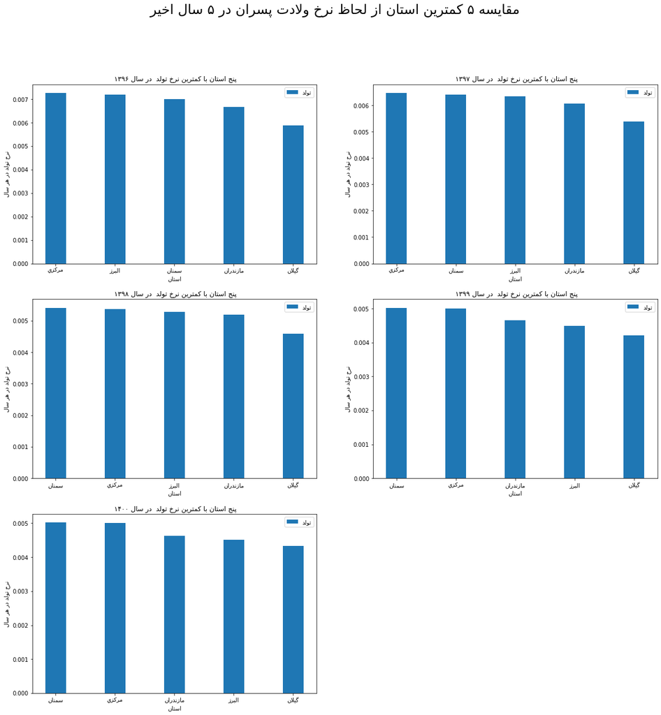

```python
df_rate_96 = make_df_of_rate(df_popu,man_96)
df_rate_97 = make_df_of_rate(df_popu,man_97)
df_rate_98 = make_df_of_rate(df_popu,man_98)
df_rate_99 = make_df_of_rate(df_popu,man_99)
df_rate_1400 = make_df_of_rate(df_popu,man_1400)


width = 0.35
fig, ax = plt.subplots(3,2,figsize = [20,20])
fig.delaxes(ax[2,1])
#
ax[0,0].bar(df_rate_96['ostan'].tail(5), df_rate_96['nesbat'].tail(5), width,label=( to_persian(u'تولد')))
ax[0,0].set_ylabel( to_persian(u'نرخ تولد در هر سال'))
ax[0,0].set_title( to_persian(u'پنج استان با کمترین نرخ تولد  در سال ۱۳۹۶ '))
ax[0,0].set_xlabel( to_persian(u'استان'))
ax[0,0].legend()
#
ax[0,1].bar(df_rate_97['ostan'].tail(5), df_rate_97['nesbat'].tail(5), width,label=( to_persian(u'تولد')))
ax[0,1].set_ylabel( to_persian(u'نرخ تولد در هر سال'))
ax[0,1].set_title( to_persian(u'پنج استان با کمترین نرخ تولد  در سال ۱۳۹۷ '))
ax[0,1].set_xlabel( to_persian(u'استان'))
ax[0,1].legend()
#
ax[1,0].bar(df_rate_98['ostan'].tail(5), df_rate_98['nesbat'].tail(5), width,label=( to_persian(u'تولد')))
ax[1,0].set_ylabel( to_persian(u'نرخ تولد در هر سال'))
ax[1,0].set_title( to_persian(u'پنج استان با کمترین نرخ تولد  در سال ۱۳۹۸ '))
ax[1,0].set_xlabel( to_persian(u'استان'))
ax[1,0].legend()
#
ax[1,1].bar(df_rate_99['ostan'].tail(5), df_rate_99['nesbat'].tail(5), width,label=( to_persian(u'تولد')))
ax[1,1].set_ylabel( to_persian(u'نرخ تولد در هر سال'))
ax[1,1].set_title( to_persian(u'پنج استان با کمترین نرخ تولد  در سال ۱۳۹۹ '))
ax[1,1].set_xlabel( to_persian(u'استان'))
ax[1,1].legend()
#
ax[2,0].bar(df_rate_1400['ostan'].tail(5), df_rate_1400['nesbat'].tail(5), width,label=( to_persian(u'تولد')))
ax[2,0].set_ylabel( to_persian(u'نرخ تولد در هر سال'))
ax[2,0].set_title( to_persian(u'پنج استان با کمترین نرخ تولد  در سال ۱۴۰۰ '))
ax[2,0].set_xlabel( to_persian(u'استان'))
ax[2,0].legend()
fig.suptitle(to_persian(u'مقایسه ۵ کمترین استان از لحاظ نرخ ولادت پسران در ۵ سال اخیر')  ,size=24) # or plt.suptitle('Main title')
plt.show()
```

##### **g. Birth number and rate in each season!**

```python
try:
    # Connect to an existing database
    connection = psycopg2.connect(user="postgres",
                                  password="admin",
                                  host= "localhost",
                                  port="5432",
                                  database="birthDB")

    # Create a cursor to perform database operations
    cursor = connection.cursor()
    # Executing a SQL query

    query_statement_men = """ SELECT fasl, SUM(_sum) AS sum_birth
    FROM public.iran_birth
    WHERE saal = 96
    GROUP BY fasl
    ORDER BY sum_birth ASC
    LIMIT 5
    """
    cursor.execute(query_statement_men)
    record = cursor.fetchall()
    birth_96 = record

    query_statement_men = """ SELECT fasl, SUM(_sum) AS sum_birth
    FROM public.iran_birth
    WHERE saal = 97
    GROUP BY fasl
    ORDER BY sum_birth ASC
    LIMIT 5
    """
    cursor.execute(query_statement_men)
    record = cursor.fetchall()
    birth_97 = record

    query_statement_men = """ SELECT fasl, SUM(_sum) AS sum_birth
    FROM public.iran_birth
    WHERE saal = 98
    GROUP BY fasl
    ORDER BY sum_birth ASC
    LIMIT 5
    """
    cursor.execute(query_statement_men)
    record = cursor.fetchall()
    birth_98 = record

    query_statement_men = """ SELECT fasl, SUM(_sum) AS sum_birth
    FROM public.iran_birth
    WHERE saal = 99
    GROUP BY fasl
    ORDER BY sum_birth ASC
    LIMIT 5
    """
    cursor.execute(query_statement_men)
    record = cursor.fetchall()
    birth_99 = record

    query_statement_men = """ SELECT fasl, SUM(_sum) AS sum_birth
    FROM public.iran_birth
    WHERE saal = 1400
    GROUP BY fasl
    ORDER BY sum_birth ASC
    LIMIT 5
    """
    cursor.execute(query_statement_men)
    record = cursor.fetchall()
    birth_1400 = record


    ########################################################

    query_statement_men = """ SELECT fasl, SUM(man) AS sum_birth
    FROM public.iran_birth
    WHERE saal = 96
    GROUP BY fasl
    ORDER BY sum_birth ASC
    LIMIT 5
    """
    cursor.execute(query_statement_men)
    record = cursor.fetchall()
    man_96 = record

    query_statement_men = """ SELECT fasl, SUM(man) AS sum_birth
    FROM public.iran_birth
    WHERE saal = 97
    GROUP BY fasl
    ORDER BY sum_birth ASC
    LIMIT 5
    """
    cursor.execute(query_statement_men)
    record = cursor.fetchall()
    man_97 = record

    query_statement_men = """ SELECT fasl, SUM(man) AS sum_birth
    FROM public.iran_birth
    WHERE saal = 98
    GROUP BY fasl
    ORDER BY sum_birth ASC
    LIMIT 5
    """
    cursor.execute(query_statement_men)
    record = cursor.fetchall()
    man_98 = record

    query_statement_men = """ SELECT fasl, SUM(man) AS sum_birth
    FROM public.iran_birth
    WHERE saal = 99
    GROUP BY fasl
    ORDER BY sum_birth ASC
    LIMIT 5
    """
    cursor.execute(query_statement_men)
    record = cursor.fetchall()
    man_99 = record

    query_statement_men = """ SELECT fasl, SUM(man) AS sum_birth
    FROM public.iran_birth
    WHERE saal = 1400
    GROUP BY fasl
    ORDER BY sum_birth ASC
    LIMIT 5
    """
    cursor.execute(query_statement_men)
    record = cursor.fetchall()
    man_1400 = record


#################################################################
    query_statement_men = """ SELECT fasl, SUM(woman) AS sum_birth
    FROM public.iran_birth
    WHERE saal = 96
    GROUP BY fasl
    ORDER BY sum_birth ASC
    LIMIT 5
    """
    cursor.execute(query_statement_men)
    record = cursor.fetchall()
    woman_96 = record

    query_statement_men = """ SELECT fasl, SUM(woman) AS sum_birth
    FROM public.iran_birth
    WHERE saal = 97
    GROUP BY fasl
    ORDER BY sum_birth ASC
    LIMIT 5
    """
    cursor.execute(query_statement_men)
    record = cursor.fetchall()
    woman_97 = record

    query_statement_men = """ SELECT fasl, SUM(woman) AS sum_birth
    FROM public.iran_birth
    WHERE saal = 98
    GROUP BY fasl
    ORDER BY sum_birth ASC
    LIMIT 5
    """
    cursor.execute(query_statement_men)
    record = cursor.fetchall()
    woman_98 = record

    query_statement_men = """ SELECT fasl, SUM(woman) AS sum_birth
    FROM public.iran_birth
    WHERE saal = 99
    GROUP BY fasl
    ORDER BY sum_birth ASC
    LIMIT 5
    """
    cursor.execute(query_statement_men)
    record = cursor.fetchall()
    woman_99 = record

    query_statement_men = """ SELECT fasl, SUM(woman) AS sum_birth
    FROM public.iran_birth
    WHERE saal = 1400
    GROUP BY fasl
    ORDER BY sum_birth ASC
    LIMIT 5
    """
    cursor.execute(query_statement_men)
    record = cursor.fetchall()
    woman_1400 = record



except (Exception, Error) as error:
    print("Error while connecting to PostgreSQL", error)
finally:
    if (connection):
        cursor.close()
        connection.close()
        print("PostgreSQL connection is closed")
```

```
PostgreSQL connection is closed
```

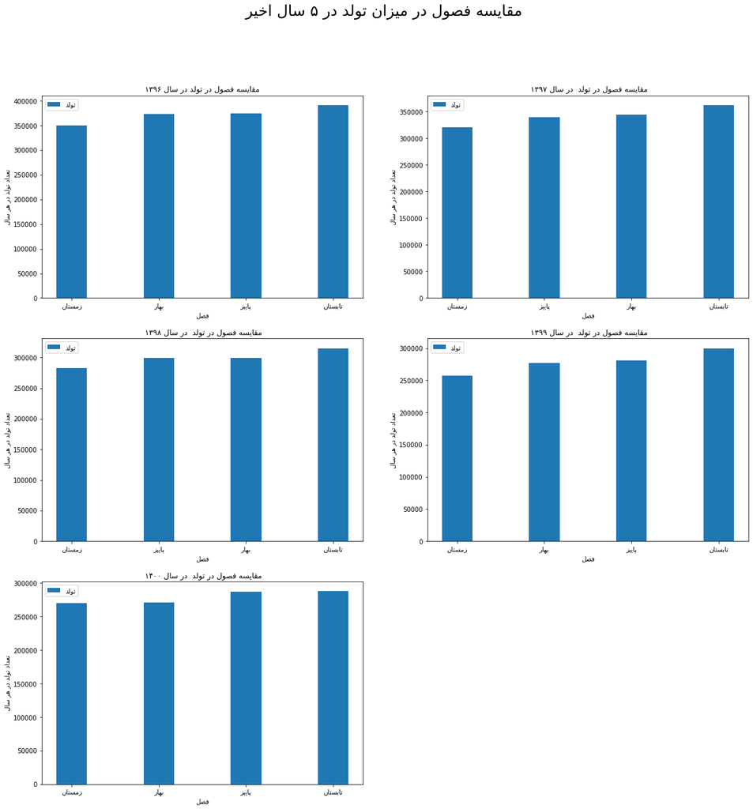

```python
x_96 = [get_display(reshape(x[0])) for x in birth_96] #pesky fix!
y_96 = [x[1] for x in birth_96]
#
x_97 = [get_display(reshape(x[0])) for x in birth_97] #pesky fix!
y_97 = [x[1] for x in birth_97]
#
x_98 = [get_display(reshape(x[0])) for x in birth_98] #pesky fix!
y_98 = [x[1] for x in birth_98]
#
x_99 = [get_display(reshape(x[0])) for x in birth_96] #pesky fix!
y_99 = [x[1] for x in birth_99]
#
x_1400 = [get_display(reshape(x[0])) for x in birth_96] #pesky fix!
y_1400 = [x[1] for x in birth_1400]

width = 0.35       # the width of the bars: can also be len(x) sequence
fig, ax = plt.subplots(3,2,figsize = [20,20])
fig.delaxes(ax[2,1]) #The indexing is zero-based here
#
ax[0,0].bar(x_96, y_96, width,label=( to_persian(u'تولد')))
ax[0,0].set_ylabel( to_persian(u'تعداد تولد در هر سال'))
ax[0,0].set_title( to_persian(u' مقایسه فصول در تولد در سال ۱۳۹۶ '))
ax[0,0].set_xlabel( to_persian(u'فصل'))
ax[0,0].legend()
#
ax[0,1].bar(x_97, y_97, width,label=( to_persian(u'تولد')))
ax[0,1].set_ylabel( to_persian(u'تعداد تولد در هر سال'))
ax[0,1].set_title( to_persian(u'مقایسه فصول در تولد  در سال ۱۳۹۷ '))
ax[0,1].set_xlabel( to_persian(u'فصل'))
ax[0,1].legend()
#
ax[1,0].bar(x_98, y_98, width,label=( to_persian(u'تولد')))
ax[1,0].set_ylabel( to_persian(u'تعداد تولد در هر سال'))
ax[1,0].set_title( to_persian(u'مقایسه فصول در تولد  در سال ۱۳۹۸ '))
ax[1,0].set_xlabel( to_persian(u'فصل'))
ax[1,0].legend()
#
ax[1,1].bar(x_99, y_99, width,label=( to_persian(u'تولد')))
ax[1,1].set_ylabel( to_persian(u'تعداد تولد در هر سال'))
ax[1,1].set_title( to_persian(u'مقایسه فصول در تولد  در سال ۱۳۹۹ '))
ax[1,1].set_xlabel( to_persian(u'فصل'))
ax[1,1].legend()
#
ax[2,0].bar(x_1400, y_1400, width,label=( to_persian(u'تولد')))
ax[2,0].set_ylabel( to_persian(u'تعداد تولد در هر سال'))
ax[2,0].set_title( to_persian(u'مقایسه فصول در تولد  در سال ۱۴۰۰ '))
ax[2,0].set_xlabel( to_persian(u'فصل'))
ax[2,0].legend()
fig.suptitle(to_persian(u' مقایسه فصول در میزان تولد در ۵ سال اخیر ')  ,size=24) # or plt.suptitle('Main title')

plt.show()
```

همانطور که در نمودار بالا می بینیم فصل تابستان در تمامی سال ها بیشترین تعداد متولدین را داشته است. همینطور زمستان نیز در تمامی سال ها کمترین مقدار متولدین را داشته است. اما ترتیب پاییز و بهار در برخی سال ها با هم جابجا شده است.

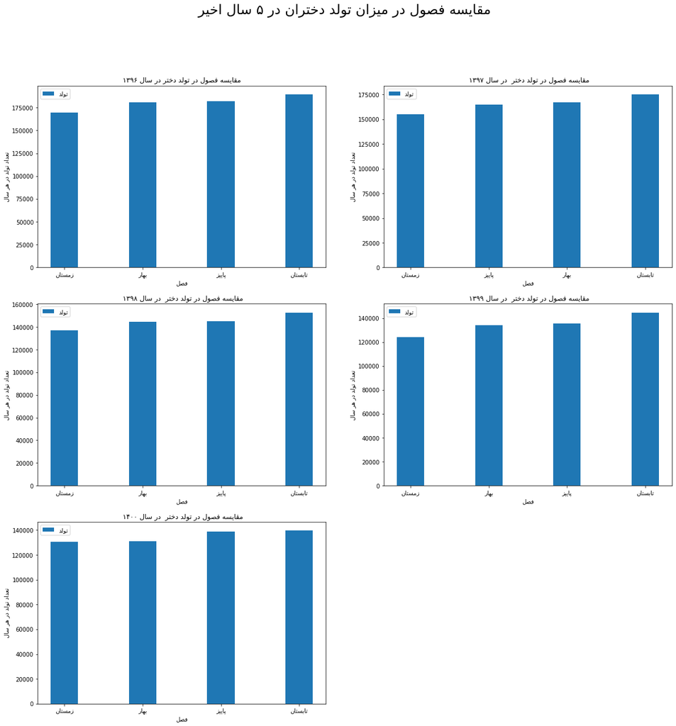

```python
x_96 = [get_display(reshape(x[0])) for x in woman_96] #pesky fix!
y_96 = [x[1] for x in woman_96]
#
x_97 = [get_display(reshape(x[0])) for x in woman_97] #pesky fix!
y_97 = [x[1] for x in woman_97]
#
x_98 = [get_display(reshape(x[0])) for x in woman_98] #pesky fix!
y_98 = [x[1] for x in woman_98]
#
x_99 = [get_display(reshape(x[0])) for x in woman_96] #pesky fix!
y_99 = [x[1] for x in woman_99]
#
x_1400 = [get_display(reshape(x[0])) for x in woman_96] #pesky fix!
y_1400 = [x[1] for x in woman_1400]

width = 0.35       # the width of the bars: can also be len(x) sequence
fig, ax = plt.subplots(3,2,figsize = [20,20])
fig.delaxes(ax[2,1]) #The indexing is zero-based here
#
ax[0,0].bar(x_96, y_96, width,label=( to_persian(u'تولد')))
ax[0,0].set_ylabel( to_persian(u'تعداد تولد در هر سال'))
ax[0,0].set_title( to_persian(u' مقایسه فصول در تولد دختر در سال ۱۳۹۶ '))
ax[0,0].set_xlabel( to_persian(u'فصل'))
ax[0,0].legend()
#
ax[0,1].bar(x_97, y_97, width,label=( to_persian(u'تولد')))
ax[0,1].set_ylabel( to_persian(u'تعداد تولد در هر سال'))
ax[0,1].set_title( to_persian(u'مقایسه فصول در تولد دختر  در سال ۱۳۹۷ '))
ax[0,1].set_xlabel( to_persian(u'فصل'))
ax[0,1].legend()
#
ax[1,0].bar(x_98, y_98, width,label=( to_persian(u'تولد')))
ax[1,0].set_ylabel( to_persian(u'تعداد تولد در هر سال'))
ax[1,0].set_title( to_persian(u'مقایسه فصول در تولد دختر  در سال ۱۳۹۸ '))
ax[1,0].set_xlabel( to_persian(u'فصل'))
ax[1,0].legend()
#
ax[1,1].bar(x_99, y_99, width,label=( to_persian(u'تولد')))
ax[1,1].set_ylabel( to_persian(u'تعداد تولد در هر سال'))
ax[1,1].set_title( to_persian(u'مقایسه فصول در تولد دختر  در سال ۱۳۹۹ '))
ax[1,1].set_xlabel( to_persian(u'فصل'))
ax[1,1].legend()
#
ax[2,0].bar(x_1400, y_1400, width,label=( to_persian(u'تولد')))
ax[2,0].set_ylabel( to_persian(u'تعداد تولد در هر سال'))
ax[2,0].set_title( to_persian(u'مقایسه فصول در تولد دختر  در سال ۱۴۰۰ '))
ax[2,0].set_xlabel( to_persian(u'فصل'))
ax[2,0].legend()
fig.suptitle(to_persian(u' مقایسه فصول در میزان تولد دختران در ۵ سال اخیر ')  ,size=24) # or plt.suptitle('Main title')

plt.show()
```

همانطور که در نمودار بالا می بینیم فصل تابستان در تمامی سال ها بیشترین تعداد متولدین را داشته است. همینطور زمستان نیز در تمامی سال ها کمترین مقدار متولدین را داشته است. اما ترتیب پاییز و بهار در برخی سال ها با هم جابجا شده است.

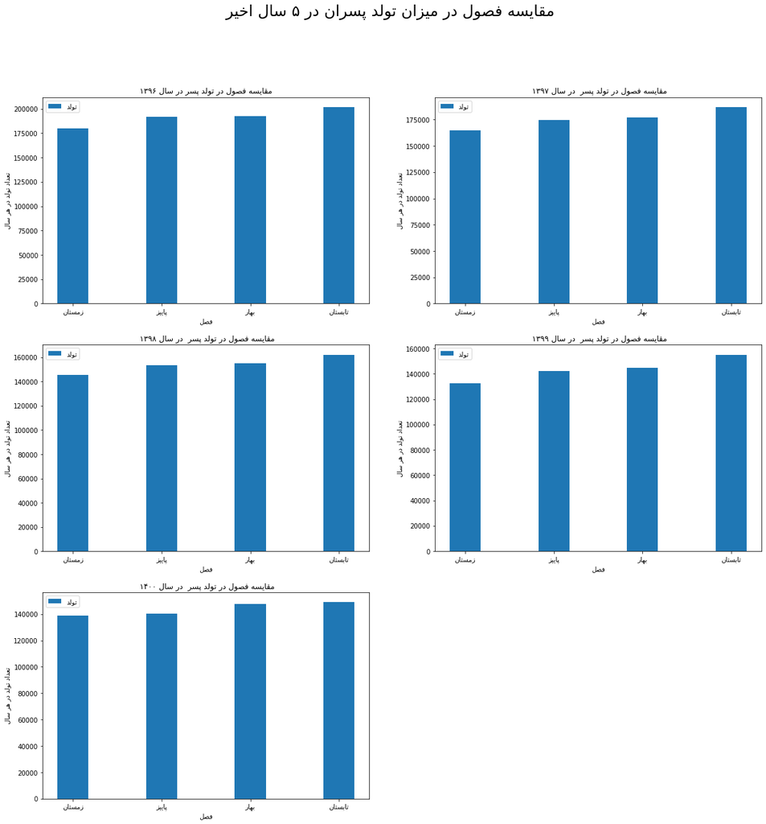

```python
x_96 = [get_display(reshape(x[0])) for x in man_96] #pesky fix!
y_96 = [x[1] for x in man_96]
#
x_97 = [get_display(reshape(x[0])) for x in man_97] #pesky fix!
y_97 = [x[1] for x in man_97]
#
x_98 = [get_display(reshape(x[0])) for x in man_98] #pesky fix!
y_98 = [x[1] for x in man_98]
#
x_99 = [get_display(reshape(x[0])) for x in man_96] #pesky fix!
y_99 = [x[1] for x in man_99]
#
x_1400 = [get_display(reshape(x[0])) for x in man_96] #pesky fix!
y_1400 = [x[1] for x in man_1400]

width = 0.35       # the width of the bars: can also be len(x) sequence
fig, ax = plt.subplots(3,2,figsize = [20,20])
fig.delaxes(ax[2,1]) #The indexing is zero-based here
#
ax[0,0].bar(x_96, y_96, width,label=( to_persian(u'تولد')))
ax[0,0].set_ylabel( to_persian(u'تعداد تولد در هر سال'))
ax[0,0].set_title( to_persian(u' مقایسه فصول در تولد پسر در سال ۱۳۹۶ '))
ax[0,0].set_xlabel( to_persian(u'فصل'))
ax[0,0].legend()
#
ax[0,1].bar(x_97, y_97, width,label=( to_persian(u'تولد')))
ax[0,1].set_ylabel( to_persian(u'تعداد تولد در هر سال'))
ax[0,1].set_title( to_persian(u'مقایسه فصول در تولد پسر  در سال ۱۳۹۷ '))
ax[0,1].set_xlabel( to_persian(u'فصل'))
ax[0,1].legend()
#
ax[1,0].bar(x_98, y_98, width,label=( to_persian(u'تولد')))
ax[1,0].set_ylabel( to_persian(u'تعداد تولد در هر سال'))
ax[1,0].set_title( to_persian(u'مقایسه فصول در تولد پسر  در سال ۱۳۹۸ '))
ax[1,0].set_xlabel( to_persian(u'فصل'))
ax[1,0].legend()
#
ax[1,1].bar(x_99, y_99, width,label=( to_persian(u'تولد')))
ax[1,1].set_ylabel( to_persian(u'تعداد تولد در هر سال'))
ax[1,1].set_title( to_persian(u'مقایسه فصول در تولد پسر  در سال ۱۳۹۹ '))
ax[1,1].set_xlabel( to_persian(u'فصل'))
ax[1,1].legend()
#
ax[2,0].bar(x_1400, y_1400, width,label=( to_persian(u'تولد')))
ax[2,0].set_ylabel( to_persian(u'تعداد تولد در هر سال'))
ax[2,0].set_title( to_persian(u'مقایسه فصول در تولد پسر  در سال ۱۴۰۰ '))
ax[2,0].set_xlabel( to_persian(u'فصل'))
ax[2,0].legend()
fig.suptitle(to_persian(u' مقایسه فصول در میزان تولد پسران در ۵ سال اخیر ')  ,size=24) # or plt.suptitle('Main title')

plt.show()
```

## Question 3 :

What are the disadvantages of cursors?

- Uses more resources because Each time you fetch a row from the cursor, it results in a network roundtrip.
- There are restrictions on the SELECT statements that can be used.
- Because of the round trips, performance and speed is slow.

It is true that in some case we can avoid cursors by using PL SQL logics,I mean by implementing While loop,Tricky queries and through joins but they require great development logic.

If possible, avoid using SQL Server cursors. They generally use a lot of SQL Server resources and reduce the performance and scalability of your applications. If you need to perform row-by-row operations, try to find another method to perform the task.

Here are some alternatives to using a cursor:

- Use WHILE LOOPS
- Use temp tables
- Use derived tables

## **Part2 - Working with QGIS**

#### **Section A: Load Data**

در این قسمت می خواهیم با نرم افزار QGIS آشنایی پیدا کنیم. برای این کار ابتدا نرم افزار را نصب می کنیم. سپس ماژول PostGIS را نصب میکنیم. حال یک پایگاه داده با نام Iran_Country را می سازیم و با استفاده از دستور گفته شده ماژول PostGIS را نصب میکنیم و سپس ۳ عدد فایل SQL داده شده را در آن وارد می کنیم. در ادامه در نرم افزار QGIS به پایگاه داده وصل می شویم و لایه های جدید را اضافه می کنیم. شکلی که برای مرحله اول بدست می آید به صورت زیر است.

[figure not shown]

#### **Section B: Answer Questions**

### A:

در این قسمت با استفاده از query هایی که می نویسیم می خواهیم لوکیشن مکان های داده شده را بدست اوریم. کوری و نتیجه آن در قسمت زیر نمایش داده شده است.

```python
SELECT iran_county.name_1 as County , iran_states.name_1 as State
from iran_county,iran_states
where ST_Intersects(iran_county.wkb_geometry,ST_GeomFromText('POINT(51.3380650 35.6997300)',4326)) and
ST_Intersects(iran_states.wkb_geometry,ST_GeomFromText('POINT(51.3380650 35.6997300)',4326));
```

[figure not shown]

Answer of a: Tehran - Tehran

### B:

```python
SELECT iran_county.name_1 as County , iran_states.name_1 as State
from iran_county,iran_states
where ST_Intersects(iran_county.wkb_geometry,ST_GeomFromText('POINT(52.8904157 29.9351594)',4326)) and
ST_Intersects(iran_states.wkb_geometry,ST_GeomFromText('POINT(52.8904157 29.9351594)',4326));
```

[figure not shown]

Answer of b: Fars - Fars

### C:

در این قسمت فایل iran_inland_waters.sql هم به فایل های قبلی اضافه کرده و یک لایه به نقشه اضافه می کنیم که شکل زیر بدست می اید.

[figure not shown]

### D:

```python
SELECT iran_inland_water.name as name,iran_county.name_1 as County , iran_states.name_1 as State
from iran_county,iran_states,iran_inland_water
where ST_Intersects(iran_county.wkb_geometry,ST_GeomFromText('POINT(51.270365 35.728517)',4326)) and
ST_Intersects(iran_states.wkb_geometry,ST_GeomFromText('POINT(51.270365 35.728517)',4326)) and
ST_Intersects(iran_inland_water.wkb_geometry,ST_GeomFromText('POINT(51.270365 35.728517)',4326)) ;
```

[figure not shown]

Location : UNK - Tehran - Tehran

```python
SELECT iran_inland_water.name as name,iran_county.name_1 as County , iran_states.name_1 as State
from iran_county,iran_states,iran_inland_water
where ST_Intersects(iran_county.wkb_geometry,ST_GeomFromText('POINT(51.270365 35.728517)',4326)) and
ST_Intersects(iran_states.wkb_geometry,ST_GeomFromText('POINT(51.270365 35.728517)',4326)) and
ST_Intersects(iran_inland_water.wkb_geometry,ST_GeomFromText('POINT(51.270365 35.728517)',4326)) ;
```

[figure not shown]